# Project: Data Wrangling

## 1- Gathering Data

```python
#Import the libraries used for gathering data
import pandas as pd
import requests
import tweepy
import json
import numpy as np
import matplotlib.pyplot as plt
```

### The WeRateDogs Twitter archive:

```python
#Read in the twitter archive data and save it to a Pandas DataFrame
twitter_archive = pd.read_csv('twitter-archive-enhanced.csv')
```

```python
#Make sure our file was downloaded correctly
twitter_archive.head()
```

|  | tweet_id | in_reply_to_status_id | in_reply_to_user_id | timestamp | source | text | retweeted_status_id | retweeted_status_user_id | retweeted_status_timestamp | expanded_urls | rating_numerator | rating_denominator | name | doggo | floofer | pupper | puppo |
| --- | --- | --- | --- | --- | --- | --- | --- | --- | --- | --- | --- | --- | --- | --- | --- | --- | --- |
| 0 | 892420643555336193 | NaN | NaN | 2017-08-01 16:23:56 +0000 | <a href="http://twitter.com/download/iphone" r... | This is Phineas. He's a mystical boy. Only eve... | NaN | NaN | NaN | https://twitter.com/dog_rates/status/892420643... | 13 | 10 | Phineas | None | None | None | None |
| 1 | 892177421306343426 | NaN | NaN | 2017-08-01 00:17:27 +0000 | <a href="http://twitter.com/download/iphone" r... | This is Tilly. She's just checking pup on you.... | NaN | NaN | NaN | https://twitter.com/dog_rates/status/892177421... | 13 | 10 | Tilly | None | None | None | None |
| 2 | 891815181378084864 | NaN | NaN | 2017-07-31 00:18:03 +0000 | <a href="http://twitter.com/download/iphone" r... | This is Archie. He is a rare Norwegian Pouncin... | NaN | NaN | NaN | https://twitter.com/dog_rates/status/891815181... | 12 | 10 | Archie | None | None | None | None |
| 3 | 891689557279858688 | NaN | NaN | 2017-07-30 15:58:51 +0000 | <a href="http://twitter.com/download/iphone" r... | This is Darla. She commenced a snooze mid meal... | NaN | NaN | NaN | https://twitter.com/dog_rates/status/891689557... | 13 | 10 | Darla | None | None | None | None |
| 4 | 891327558926688256 | NaN | NaN | 2017-07-29 16:00:24 +0000 | <a href="http://twitter.com/download/iphone" r... | This is Franklin. He would like you to stop ca... | NaN | NaN | NaN | https://twitter.com/dog_rates/status/891327558... | 12 | 10 | Franklin | None | None | None | None |

### The Tweet Image Predictions:

```python
#Request the URL where the file is stored and
#save it to response variable
url =  'https://d17h27t6h515a5.cloudfront.net/topher/2017/August/599fd2ad_image-predictions/image-predictions.tsv'
response = requests.get(url)

#Open a new file, image_predictions.tsv, and save the
#content of the response variable to it
with open('image_predictions.tsv', mode = 'wb') as file:
    file.write(response.content)
```

```python
#Read in the new file we created and save it to a Pandas DataFrame
image_predictions = pd.read_csv('image_predictions.tsv', sep = '\t')
```

```python
#Make sure our file was downloaded correctly
image_predictions.head()
```

|  | tweet_id | jpg_url | img_num | p1 | p1_conf | p1_dog | p2 | p2_conf | p2_dog | p3 | p3_conf | p3_dog |
| --- | --- | --- | --- | --- | --- | --- | --- | --- | --- | --- | --- | --- |
| 0 | 666020888022790149 | https://pbs.twimg.com/media/CT4udn0WwAA0aMy.jpg | 1 | Welsh_springer_spaniel | 0.465074 | True | collie | 0.156665 | True | Shetland_sheepdog | 0.061428 | True |
| 1 | 666029285002620928 | https://pbs.twimg.com/media/CT42GRgUYAA5iDo.jpg | 1 | redbone | 0.506826 | True | miniature_pinscher | 0.074192 | True | Rhodesian_ridgeback | 0.072010 | True |
| 2 | 666033412701032449 | https://pbs.twimg.com/media/CT4521TWwAEvMyu.jpg | 1 | German_shepherd | 0.596461 | True | malinois | 0.138584 | True | bloodhound | 0.116197 | True |
| 3 | 666044226329800704 | https://pbs.twimg.com/media/CT5Dr8HUEAA-lEu.jpg | 1 | Rhodesian_ridgeback | 0.408143 | True | redbone | 0.360687 | True | miniature_pinscher | 0.222752 | True |
| 4 | 666049248165822465 | https://pbs.twimg.com/media/CT5IQmsXIAAKY4A.jpg | 1 | miniature_pinscher | 0.560311 | True | Rottweiler | 0.243682 | True | Doberman | 0.154629 | True |

### Retweet and favorite counts:

```python
#Set up Tweepy
consumer_key = #deleted
consumer_secret = #deleted
access_token = #deleted
access_secret = #deleted

auth = tweepy.OAuthHandler(consumer_key, consumer_secret)
auth.set_access_token(access_token, access_secret)

api = tweepy.API(auth, wait_on_rate_limit = True, wait_on_rate_limit_notify = True)
```

```python
#Iterate through the tweet ids and get the status of each tweet
#If the tweet was deleted, add its id to the deleted_tweets list
tweet_info = []
deleted_tweets = []

for id_of_tweet in twitter_archive['tweet_id']:
    try:
        json_info = api.get_status(id_of_tweet, tweet_mode='extended')._json
        tweet_info.append(json_info)
        print(id_of_tweet)
    except:
        deleted_tweets.append(id_of_tweet)
        print("ID not found")
```

[output not shown]

[output cut: 2303 more lines]

[output not shown]

```python
#Iterate through the list we created and write all the tweet information to the output file
with open('tweet_json.txt', 'w') as outfile:
    for element in tweet_info:
        json.dump(element, outfile)
        outfile.write('\n')
```

```python
#Write output file to a Pandas Data Frame by reading each line as a json object
tweet_info_df = pd.read_json('tweet_json.txt', lines = True)
```

```python
#Make sure the new Data Frame was created and check which columns we need
tweet_info_df.info()
```

```
<class 'pandas.core.frame.DataFrame'>
RangeIndex: 2339 entries, 0 to 2338
Data columns (total 32 columns):
contributors                     0 non-null float64
coordinates                      0 non-null float64
created_at                       2339 non-null datetime64[ns]
display_text_range               2339 non-null object
entities                         2339 non-null object
extended_entities                2065 non-null object
favorite_count                   2339 non-null int64
favorited                        2339 non-null bool
full_text                        2339 non-null object
geo                              0 non-null float64
id                               2339 non-null int64
id_str                           2339 non-null int64
in_reply_to_screen_name          77 non-null object
in_reply_to_status_id            77 non-null float64
in_reply_to_status_id_str        77 non-null float64
in_reply_to_user_id              77 non-null float64
in_reply_to_user_id_str          77 non-null float64
is_quote_status                  2339 non-null bool
lang                             2339 non-null object
place                            1 non-null object
possibly_sensitive               2203 non-null float64
possibly_sensitive_appealable    2203 non-null float64
quoted_status                    24 non-null object
quoted_status_id                 26 non-null float64
quoted_status_id_str             26 non-null float64
quoted_status_permalink          26 non-null object
retweet_count                    2339 non-null int64
retweeted                        2339 non-null bool
retweeted_status                 167 non-null object
source                           2339 non-null object
truncated                        2339 non-null bool
user                             2339 non-null object
dtypes: bool(4), datetime64[ns](1), float64(11), int64(4), object(12)
memory usage: 520.9+ KB
```

```python
# Use only the information we need from the data frame
additional_tweet_info = tweet_info_df[['id', 'favorite_count', 'retweet_count']]
```

```python
#Make sure we have the correct columns
additional_tweet_info.head()
```

|  | id | favorite_count | retweet_count |
| --- | --- | --- | --- |
| 0 | 892420643555336193 | 37672 | 8213 |
| 1 | 892177421306343426 | 32353 | 6073 |
| 2 | 891815181378084864 | 24373 | 4015 |
| 3 | 891689557279858688 | 40993 | 8369 |
| 4 | 891327558926688256 | 39191 | 9072 |

## Assessing Data

```python
twitter_archive
```

|  | tweet_id | in_reply_to_status_id | in_reply_to_user_id | timestamp | source | text | retweeted_status_id | retweeted_status_user_id | retweeted_status_timestamp | expanded_urls | rating_numerator | rating_denominator | name | doggo | floofer | pupper | puppo |
| --- | --- | --- | --- | --- | --- | --- | --- | --- | --- | --- | --- | --- | --- | --- | --- | --- | --- |
| 0 | 892420643555336193 | NaN | NaN | 2017-08-01 16:23:56 +0000 | <a href="http://twitter.com/download/iphone" rel="nofollow">Twitter for iPhone</a> | This is Phineas. He's a mystical boy. Only ever appears in the hole of a donut. 13/10 https://t.co/MgUWQ76dJU | NaN | NaN | NaN | https://twitter.com/dog_rates/status/892420643555336193/photo/1 | 13 | 10 | Phineas | None | None | None | None |
| 1 | 892177421306343426 | NaN | NaN | 2017-08-01 00:17:27 +0000 | <a href="http://twitter.com/download/iphone" rel="nofollow">Twitter for iPhone</a> | This is Tilly. She's just checking pup on you. Hopes you're doing ok. If not, she's available for pats, snugs, boops, the whole bit. 13/10 https://t.co/0Xxu71qeIV | NaN | NaN | NaN | https://twitter.com/dog_rates/status/892177421306343426/photo/1 | 13 | 10 | Tilly | None | None | None | None |
| 2 | 891815181378084864 | NaN | NaN | 2017-07-31 00:18:03 +0000 | <a href="http://twitter.com/download/iphone" rel="nofollow">Twitter for iPhone</a> | This is Archie. He is a rare Norwegian Pouncing Corgo. Lives in the tall grass. You never know when one may strike. 12/10 https://t.co/wUnZnhtVJB | NaN | NaN | NaN | https://twitter.com/dog_rates/status/891815181378084864/photo/1 | 12 | 10 | Archie | None | None | None | None |
| 3 | 891689557279858688 | NaN | NaN | 2017-07-30 15:58:51 +0000 | <a href="http://twitter.com/download/iphone" rel="nofollow">Twitter for iPhone</a> | This is Darla. She commenced a snooze mid meal. 13/10 happens to the best of us https://t.co/tD36da7qLQ | NaN | NaN | NaN | https://twitter.com/dog_rates/status/891689557279858688/photo/1 | 13 | 10 | Darla | None | None | None | None |
| 4 | 891327558926688256 | NaN | NaN | 2017-07-29 16:00:24 +0000 | <a href="http://twitter.com/download/iphone" rel="nofollow">Twitter for iPhone</a> | This is Franklin. He would like you to stop calling him "cute." He is a very fierce shark and should be respected as such. 12/10 #BarkWeek https://t.co/AtUZn91f7f | NaN | NaN | NaN | https://twitter.com/dog_rates/status/891327558926688256/photo/1,https://twitter.com/dog_rates/status/891327558926688256/photo/1 | 12 | 10 | Franklin | None | None | None | None |
| 5 | 891087950875897856 | NaN | NaN | 2017-07-29 00:08:17 +0000 | <a href="http://twitter.com/download/iphone" rel="nofollow">Twitter for iPhone</a> | Here we have a majestic great white breaching off South Africa's coast. Absolutely h*ckin breathtaking. 13/10 (IG: tucker_marlo) #BarkWeek https://t.co/kQ04fDDRmh | NaN | NaN | NaN | https://twitter.com/dog_rates/status/891087950875897856/photo/1 | 13 | 10 | None | None | None | None | None |
| 6 | 890971913173991426 | NaN | NaN | 2017-07-28 16:27:12 +0000 | <a href="http://twitter.com/download/iphone" rel="nofollow">Twitter for iPhone</a> | Meet Jax. He enjoys ice cream so much he gets nervous around it. 13/10 help Jax enjoy more things by clicking below\n\nhttps://t.co/Zr4hWfAs1H https://t.co/tVJBRMnhxl | NaN | NaN | NaN | https://gofundme.com/ydvmve-surgery-for-jax,https://twitter.com/dog_rates/status/890971913173991426/photo/1 | 13 | 10 | Jax | None | None | None | None |
| 7 | 890729181411237888 | NaN | NaN | 2017-07-28 00:22:40 +0000 | <a href="http://twitter.com/download/iphone" rel="nofollow">Twitter for iPhone</a> | When you watch your owner call another dog a good boy but then they turn back to you and say you're a great boy. 13/10 https://t.co/v0nONBcwxq | NaN | NaN | NaN | https://twitter.com/dog_rates/status/890729181411237888/photo/1,https://twitter.com/dog_rates/status/890729181411237888/photo/1 | 13 | 10 | None | None | None | None | None |
| 8 | 890609185150312448 | NaN | NaN | 2017-07-27 16:25:51 +0000 | <a href="http://twitter.com/download/iphone" rel="nofollow">Twitter for iPhone</a> | This is Zoey. She doesn't want to be one of the scary sharks. Just wants to be a snuggly pettable boatpet. 13/10 #BarkWeek https://t.co/9TwLuAGH0b | NaN | NaN | NaN | https://twitter.com/dog_rates/status/890609185150312448/photo/1 | 13 | 10 | Zoey | None | None | None | None |
| 9 | 890240255349198849 | NaN | NaN | 2017-07-26 15:59:51 +0000 | <a href="http://twitter.com/download/iphone" rel="nofollow">Twitter for iPhone</a> | This is Cassie. She is a college pup. Studying international doggo communication and stick theory. 14/10 so elegant much sophisticate https://t.co/t1bfwz5S2A | NaN | NaN | NaN | https://twitter.com/dog_rates/status/890240255349198849/photo/1 | 14 | 10 | Cassie | doggo | None | None | None |
| 10 | 890006608113172480 | NaN | NaN | 2017-07-26 00:31:25 +0000 | <a href="http://twitter.com/download/iphone" rel="nofollow">Twitter for iPhone</a> | This is Koda. He is a South Australian deckshark. Deceptively deadly. Frighteningly majestic. 13/10 would risk a petting #BarkWeek https://t.co/dVPW0B0Mme | NaN | NaN | NaN | https://twitter.com/dog_rates/status/890006608113172480/photo/1,https://twitter.com/dog_rates/status/890006608113172480/photo/1 | 13 | 10 | Koda | None | None | None | None |
| 11 | 889880896479866881 | NaN | NaN | 2017-07-25 16:11:53 +0000 | <a href="http://twitter.com/download/iphone" rel="nofollow">Twitter for iPhone</a> | This is Bruno. He is a service shark. Only gets out of the water to assist you. 13/10 terrifyingly good boy https://t.co/u1XPQMl29g | NaN | NaN | NaN | https://twitter.com/dog_rates/status/889880896479866881/photo/1 | 13 | 10 | Bruno | None | None | None | None |
| 12 | 889665388333682689 | NaN | NaN | 2017-07-25 01:55:32 +0000 | <a href="http://twitter.com/download/iphone" rel="nofollow">Twitter for iPhone</a> | Here's a puppo that seems to be on the fence about something haha no but seriously someone help her. 13/10 https://t.co/BxvuXk0UCm | NaN | NaN | NaN | https://twitter.com/dog_rates/status/889665388333682689/photo/1 | 13 | 10 | None | None | None | None | puppo |
| 13 | 889638837579907072 | NaN | NaN | 2017-07-25 00:10:02 +0000 | <a href="http://twitter.com/download/iphone" rel="nofollow">Twitter for iPhone</a> | This is Ted. He does his best. Sometimes that's not enough. But it's ok. 12/10 would assist https://t.co/f8dEDcrKSR | NaN | NaN | NaN | https://twitter.com/dog_rates/status/889638837579907072/photo/1,https://twitter.com/dog_rates/status/889638837579907072/photo/1 | 12 | 10 | Ted | None | None | None | None |
| 14 | 889531135344209921 | NaN | NaN | 2017-07-24 17:02:04 +0000 | <a href="http://twitter.com/download/iphone" rel="nofollow">Twitter for iPhone</a> | This is Stuart. He's sporting his favorite fanny pack. Secretly filled with bones only. 13/10 puppared puppo #BarkWeek https://t.co/y70o6h3isq | NaN | NaN | NaN | https://twitter.com/dog_rates/status/889531135344209921/photo/1 | 13 | 10 | Stuart | None | None | None | puppo |
| 15 | 889278841981685760 | NaN | NaN | 2017-07-24 00:19:32 +0000 | <a href="http://twitter.com/download/iphone" rel="nofollow">Twitter for iPhone</a> | This is Oliver. You're witnessing one of his many brutal attacks. Seems to be playing with his victim. 13/10 fr*ckin frightening #BarkWeek https://t.co/WpHvrQedPb | NaN | NaN | NaN | https://twitter.com/dog_rates/status/889278841981685760/video/1 | 13 | 10 | Oliver | None | None | None | None |
| 16 | 888917238123831296 | NaN | NaN | 2017-07-23 00:22:39 +0000 | <a href="http://twitter.com/download/iphone" rel="nofollow">Twitter for iPhone</a> | This is Jim. He found a fren. Taught him how to sit like the good boys. 12/10 for both https://t.co/chxruIOUJN | NaN | NaN | NaN | https://twitter.com/dog_rates/status/888917238123831296/photo/1 | 12 | 10 | Jim | None | None | None | None |
| 17 | 888804989199671297 | NaN | NaN | 2017-07-22 16:56:37 +0000 | <a href="http://twitter.com/download/iphone" rel="nofollow">Twitter for iPhone</a> | This is Zeke. He has a new stick. Very proud of it. Would like you to throw it for him without taking it. 13/10 would do my best https://t.co/HTQ77yNQ5K | NaN | NaN | NaN | https://twitter.com/dog_rates/status/888804989199671297/photo/1,https://twitter.com/dog_rates/status/888804989199671297/photo/1 | 13 | 10 | Zeke | None | None | None | None |
| 18 | 888554962724278272 | NaN | NaN | 2017-07-22 00:23:06 +0000 | <a href="http://twitter.com/download/iphone" rel="nofollow">Twitter for iPhone</a> | This is Ralphus. He's powering up. Attempting maximum borkdrive. 13/10 inspirational af https://t.co/YnYAFCTTiK | NaN | NaN | NaN | https://twitter.com/dog_rates/status/888554962724278272/photo/1,https://twitter.com/dog_rates/status/888554962724278272/photo/1,https://twitter.com/dog_rates/status/888554962724278272/photo/1,https://… | 13 | 10 | Ralphus | None | None | None | None |
| 19 | 888202515573088257 | NaN | NaN | 2017-07-21 01:02:36 +0000 | <a href="http://twitter.com/download/iphone" rel="nofollow">Twitter for iPhone</a> | RT @dog_rates: This is Canela. She attempted some fancy porch pics. They were unsuccessful. 13/10 someone help her https://t.co/cLyzpcUcMX | 8.874740e+17 | 4.196984e+09 | 2017-07-19 00:47:34 +0000 | https://twitter.com/dog_rates/status/887473957103951883/photo/1,https://twitter.com/dog_rates/status/887473957103951883/photo/1,https://twitter.com/dog_rates/status/887473957103951883/photo/1,https://… | 13 | 10 | Canela | None | None | None | None |
| 20 | 888078434458587136 | NaN | NaN | 2017-07-20 16:49:33 +0000 | <a href="http://twitter.com/download/iphone" rel="nofollow">Twitter for iPhone</a> | This is Gerald. He was just told he didn't get the job he interviewed for. A h*ckin injustice. 12/10 didn't want the job anyway https://t.co/DK7iDPfuRX | NaN | NaN | NaN | https://twitter.com/dog_rates/status/888078434458587136/photo/1,https://twitter.com/dog_rates/status/888078434458587136/photo/1 | 12 | 10 | Gerald | None | None | None | None |
| 21 | 887705289381826560 | NaN | NaN | 2017-07-19 16:06:48 +0000 | <a href="http://twitter.com/download/iphone" rel="nofollow">Twitter for iPhone</a> | This is Jeffrey. He has a monopoly on the pool noodles. Currently running a 'boop for two' midweek sale. 13/10 h*ckin strategic https://t.co/PhrUk20Q64 | NaN | NaN | NaN | https://twitter.com/dog_rates/status/887705289381826560/photo/1 | 13 | 10 | Jeffrey | None | None | None | None |
| 22 | 887517139158093824 | NaN | NaN | 2017-07-19 03:39:09 +0000 | <a href="http://twitter.com/download/iphone" rel="nofollow">Twitter for iPhone</a> | I've yet to rate a Venezuelan Hover Wiener. This is such an honor. 14/10 paw-inspiring af (IG: roxy.thedoxy) https://t.co/20VrLAA8ba | NaN | NaN | NaN | https://twitter.com/dog_rates/status/887517139158093824/video/1 | 14 | 10 | such | None | None | None | None |
| 23 | 887473957103951883 | NaN | NaN | 2017-07-19 00:47:34 +0000 | <a href="http://twitter.com/download/iphone" rel="nofollow">Twitter for iPhone</a> | This is Canela. She attempted some fancy porch pics. They were unsuccessful. 13/10 someone help her https://t.co/cLyzpcUcMX | NaN | NaN | NaN | https://twitter.com/dog_rates/status/887473957103951883/photo/1,https://twitter.com/dog_rates/status/887473957103951883/photo/1 | 13 | 10 | Canela | None | None | None | None |
| 24 | 887343217045368832 | NaN | NaN | 2017-07-18 16:08:03 +0000 | <a href="http://twitter.com/download/iphone" rel="nofollow">Twitter for iPhone</a> | You may not have known you needed to see this today. 13/10 please enjoy (IG: emmylouroo) https://t.co/WZqNqygEyV | NaN | NaN | NaN | https://twitter.com/dog_rates/status/887343217045368832/video/1 | 13 | 10 | None | None | None | None | None |
| 25 | 887101392804085760 | NaN | NaN | 2017-07-18 00:07:08 +0000 | <a href="http://twitter.com/download/iphone" rel="nofollow">Twitter for iPhone</a> | This... is a Jubilant Antarctic House Bear. We only rate dogs. Please only send dogs. Thank you... 12/10 would suffocate in floof https://t.co/4Ad1jzJSdp | NaN | NaN | NaN | https://twitter.com/dog_rates/status/887101392804085760/photo/1 | 12 | 10 | None | None | None | None | None |
| 26 | 886983233522544640 | NaN | NaN | 2017-07-17 16:17:36 +0000 | <a href="http://twitter.com/download/iphone" rel="nofollow">Twitter for iPhone</a> | This is Maya. She's very shy. Rarely leaves her cup. 13/10 would find her an environment to thrive in https://t.co/I6oNy0CgiT | NaN | NaN | NaN | https://twitter.com/dog_rates/status/886983233522544640/photo/1,https://twitter.com/dog_rates/status/886983233522544640/photo/1 | 13 | 10 | Maya | None | None | None | None |
| 27 | 886736880519319552 | NaN | NaN | 2017-07-16 23:58:41 +0000 | <a href="http://twitter.com/download/iphone" rel="nofollow">Twitter for iPhone</a> | This is Mingus. He's a wonderful father to his smol pup. Confirmed 13/10, but he needs your help\n\nhttps://t.co/bVi0Yr4Cff https://t.co/ISvKOSkd5b | NaN | NaN | NaN | https://www.gofundme.com/mingusneedsus,https://twitter.com/dog_rates/status/886736880519319552/photo/1,https://twitter.com/dog_rates/status/886736880519319552/photo/1 | 13 | 10 | Mingus | None | None | None | None |
| 28 | 886680336477933568 | NaN | NaN | 2017-07-16 20:14:00 +0000 | <a href="http://twitter.com/download/iphone" rel="nofollow">Twitter for iPhone</a> | This is Derek. He's late for a dog meeting. 13/10 pet...al to the metal https://t.co/BCoWue0abA | NaN | NaN | NaN | https://twitter.com/dog_rates/status/886680336477933568/photo/1 | 13 | 10 | Derek | None | None | None | None |
| 29 | 886366144734445568 | NaN | NaN | 2017-07-15 23:25:31 +0000 | <a href="http://twitter.com/download/iphone" rel="nofollow">Twitter for iPhone</a> | This is Roscoe. Another pupper fallen victim to spontaneous tongue ejections. Get the BlepiPen immediate. 12/10 deep breaths Roscoe https://t.co/RGE08MIJox | NaN | NaN | NaN | https://twitter.com/dog_rates/status/886366144734445568/photo/1,https://twitter.com/dog_rates/status/886366144734445568/photo/1 | 12 | 10 | Roscoe | None | None | pupper | None |
| ... | ... | ... | ... | ... | ... | ... | ... | ... | ... | ... | ... | ... | ... | ... | ... | ... | ... |
| 2326 | 666411507551481857 | NaN | NaN | 2015-11-17 00:24:19 +0000 | <a href="http://twitter.com/download/iphone" rel="nofollow">Twitter for iPhone</a> | This is quite the dog. Gets really excited when not in water. Not very soft tho. Bad at fetch. Can't do tricks. 2/10 https://t.co/aMCTNWO94t | NaN | NaN | NaN | https://twitter.com/dog_rates/status/666411507551481857/photo/1 | 2 | 10 | quite | None | None | None | None |
| 2327 | 666407126856765440 | NaN | NaN | 2015-11-17 00:06:54 +0000 | <a href="http://twitter.com/download/iphone" rel="nofollow">Twitter for iPhone</a> | This is a southern Vesuvius bumblegruff. Can drive a truck (wow). Made friends with 5 other nifty dogs (neat). 7/10 https://t.co/LopTBkKa8h | NaN | NaN | NaN | https://twitter.com/dog_rates/status/666407126856765440/photo/1 | 7 | 10 | a | None | None | None | None |
| 2328 | 666396247373291520 | NaN | NaN | 2015-11-16 23:23:41 +0000 | <a href="http://twitter.com/download/iphone" rel="nofollow">Twitter for iPhone</a> | Oh goodness. A super rare northeast Qdoba kangaroo mix. Massive feet. No pouch (disappointing). Seems alert. 9/10 https://t.co/Dc7b0E8qFE | NaN | NaN | NaN | https://twitter.com/dog_rates/status/666396247373291520/photo/1 | 9 | 10 | None | None | None | None | None |
| 2329 | 666373753744588802 | NaN | NaN | 2015-11-16 21:54:18 +0000 | <a href="http://twitter.com/download/iphone" rel="nofollow">Twitter for iPhone</a> | Those are sunglasses and a jean jacket. 11/10 dog cool af https://t.co/uHXrPkUEyl | NaN | NaN | NaN | https://twitter.com/dog_rates/status/666373753744588802/photo/1 | 11 | 10 | None | None | None | None | None |
| 2330 | 666362758909284353 | NaN | NaN | 2015-11-16 21:10:36 +0000 | <a href="http://twitter.com/download/iphone" rel="nofollow">Twitter for iPhone</a> | Unique dog here. Very small. Lives in container of Frosted Flakes (?). Short legs. Must be rare 6/10 would still pet https://t.co/XMD9CwjEnM | NaN | NaN | NaN | https://twitter.com/dog_rates/status/666362758909284353/photo/1 | 6 | 10 | None | None | None | None | None |
| 2331 | 666353288456101888 | NaN | NaN | 2015-11-16 20:32:58 +0000 | <a href="http://twitter.com/download/iphone" rel="nofollow">Twitter for iPhone</a> | Here we have a mixed Asiago from the Galápagos Islands. Only one ear working. Big fan of marijuana carpet. 8/10 https://t.co/tltQ5w9aUO | NaN | NaN | NaN | https://twitter.com/dog_rates/status/666353288456101888/photo/1 | 8 | 10 | None | None | None | None | None |
| 2332 | 666345417576210432 | NaN | NaN | 2015-11-16 20:01:42 +0000 | <a href="http://twitter.com/download/iphone" rel="nofollow">Twitter for iPhone</a> | Look at this jokester thinking seat belt laws don't apply to him. Great tongue tho 10/10 https://t.co/VFKG1vxGjB | NaN | NaN | NaN | https://twitter.com/dog_rates/status/666345417576210432/photo/1 | 10 | 10 | None | None | None | None | None |
| 2333 | 666337882303524864 | NaN | NaN | 2015-11-16 19:31:45 +0000 | <a href="http://twitter.com/download/iphone" rel="nofollow">Twitter for iPhone</a> | This is an extremely rare horned Parthenon. Not amused. Wears shoes. Overall very nice. 9/10 would pet aggressively https://t.co/QpRjllzWAL | NaN | NaN | NaN | https://twitter.com/dog_rates/status/666337882303524864/photo/1 | 9 | 10 | an | None | None | None | None |
| 2334 | 666293911632134144 | NaN | NaN | 2015-11-16 16:37:02 +0000 | <a href="http://twitter.com/download/iphone" rel="nofollow">Twitter for iPhone</a> | This is a funny dog. Weird toes. Won't come down. Loves branch. Refuses to eat his food. Hard to cuddle with. 3/10 https://t.co/IIXis0zta0 | NaN | NaN | NaN | https://twitter.com/dog_rates/status/666293911632134144/photo/1 | 3 | 10 | a | None | None | None | None |
| 2335 | 666287406224695296 | NaN | NaN | 2015-11-16 16:11:11 +0000 | <a href="http://twitter.com/download/iphone" rel="nofollow">Twitter for iPhone</a> | This is an Albanian 3 1/2 legged Episcopalian. Loves well-polished hardwood flooring. Penis on the collar. 9/10 https://t.co/d9NcXFKwLv | NaN | NaN | NaN | https://twitter.com/dog_rates/status/666287406224695296/photo/1 | 1 | 2 | an | None | None | None | None |
| 2336 | 666273097616637952 | NaN | NaN | 2015-11-16 15:14:19 +0000 | <a href="http://twitter.com/download/iphone" rel="nofollow">Twitter for iPhone</a> | Can take selfies 11/10 https://t.co/ws2AMaNwPW | NaN | NaN | NaN | https://twitter.com/dog_rates/status/666273097616637952/photo/1 | 11 | 10 | None | None | None | None | None |
| 2337 | 666268910803644416 | NaN | NaN | 2015-11-16 14:57:41 +0000 | <a href="http://twitter.com/download/iphone" rel="nofollow">Twitter for iPhone</a> | Very concerned about fellow dog trapped in computer. 10/10 https://t.co/0yxApIikpk | NaN | NaN | NaN | https://twitter.com/dog_rates/status/666268910803644416/photo/1 | 10 | 10 | None | None | None | None | None |
| 2338 | 666104133288665088 | NaN | NaN | 2015-11-16 04:02:55 +0000 | <a href="http://twitter.com/download/iphone" rel="nofollow">Twitter for iPhone</a> | Not familiar with this breed. No tail (weird). Only 2 legs. Doesn't bark. Surprisingly quick. Shits eggs. 1/10 https://t.co/Asgdc6kuLX | NaN | NaN | NaN | https://twitter.com/dog_rates/status/666104133288665088/photo/1 | 1 | 10 | None | None | None | None | None |
| 2339 | 666102155909144576 | NaN | NaN | 2015-11-16 03:55:04 +0000 | <a href="http://twitter.com/download/iphone" rel="nofollow">Twitter for iPhone</a> | Oh my. Here you are seeing an Adobe Setter giving birth to twins!!! The world is an amazing place. 11/10 https://t.co/11LvqN4WLq | NaN | NaN | NaN | https://twitter.com/dog_rates/status/666102155909144576/photo/1 | 11 | 10 | None | None | None | None | None |
| 2340 | 666099513787052032 | NaN | NaN | 2015-11-16 03:44:34 +0000 | <a href="http://twitter.com/download/iphone" rel="nofollow">Twitter for iPhone</a> | Can stand on stump for what seems like a while. Built that birdhouse? Impressive. Made friends with a squirrel. 8/10 https://t.co/Ri4nMTLq5C | NaN | NaN | NaN | https://twitter.com/dog_rates/status/666099513787052032/photo/1 | 8 | 10 | None | None | None | None | None |
| 2341 | 666094000022159362 | NaN | NaN | 2015-11-16 03:22:39 +0000 | <a href="http://twitter.com/download/iphone" rel="nofollow">Twitter for iPhone</a> | This appears to be a Mongolian Presbyterian mix. Very tired. Tongue slip confirmed. 9/10 would lie down with https://t.co/mnioXo3IfP | NaN | NaN | NaN | https://twitter.com/dog_rates/status/666094000022159362/photo/1 | 9 | 10 | None | None | None | None | None |
| 2342 | 666082916733198337 | NaN | NaN | 2015-11-16 02:38:37 +0000 | <a href="http://twitter.com/download/iphone" rel="nofollow">Twitter for iPhone</a> | Here we have a well-established sunblockerspaniel. Lost his other flip-flop. 6/10 not very waterproof https://t.co/3RU6x0vHB7 | NaN | NaN | NaN | https://twitter.com/dog_rates/status/666082916733198337/photo/1 | 6 | 10 | None | None | None | None | None |
| 2343 | 666073100786774016 | NaN | NaN | 2015-11-16 01:59:36 +0000 | <a href="http://twitter.com/download/iphone" rel="nofollow">Twitter for iPhone</a> | Let's hope this flight isn't Malaysian (lol). What a dog! Almost completely camouflaged. 10/10 I trust this pilot https://t.co/Yk6GHE9tOY | NaN | NaN | NaN | https://twitter.com/dog_rates/status/666073100786774016/photo/1 | 10 | 10 | None | None | None | None | None |
| 2344 | 666071193221509120 | NaN | NaN | 2015-11-16 01:52:02 +0000 | <a href="http://twitter.com/download/iphone" rel="nofollow">Twitter for iPhone</a> | Here we have a northern speckled Rhododendron. Much sass. Gives 0 fucks. Good tongue. 9/10 would caress sensually https://t.co/ZoL8kq2XFx | NaN | NaN | NaN | https://twitter.com/dog_rates/status/666071193221509120/photo/1 | 9 | 10 | None | None | None | None | None |
| 2345 | 666063827256086533 | NaN | NaN | 2015-11-16 01:22:45 +0000 | <a href="http://twitter.com/download/iphone" rel="nofollow">Twitter for iPhone</a> | This is the happiest dog you will ever see. Very committed owner. Nice couch. 10/10 https://t.co/RhUEAloehK | NaN | NaN | NaN | https://twitter.com/dog_rates/status/666063827256086533/photo/1 | 10 | 10 | the | None | None | None | None |
| 2346 | 666058600524156928 | NaN | NaN | 2015-11-16 01:01:59 +0000 | <a href="http://twitter.com/download/iphone" rel="nofollow">Twitter for iPhone</a> | Here is the Rand Paul of retrievers folks! He's probably good at poker. Can drink beer (lol rad). 8/10 good dog https://t.co/pYAJkAe76p | NaN | NaN | NaN | https://twitter.com/dog_rates/status/666058600524156928/photo/1 | 8 | 10 | the | None | None | None | None |
| 2347 | 666057090499244032 | NaN | NaN | 2015-11-16 00:55:59 +0000 | <a href="http://twitter.com/download/iphone" rel="nofollow">Twitter for iPhone</a> | My oh my. This is a rare blond Canadian terrier on wheels. Only $8.98. Rather docile. 9/10 very rare https://t.co/yWBqbrzy8O | NaN | NaN | NaN | https://twitter.com/dog_rates/status/666057090499244032/photo/1 | 9 | 10 | a | None | None | None | None |
| 2348 | 666055525042405380 | NaN | NaN | 2015-11-16 00:49:46 +0000 | <a href="http://twitter.com/download/iphone" rel="nofollow">Twitter for iPhone</a> | Here is a Siberian heavily armored polar bear mix. Strong owner. 10/10 I would do unspeakable things to pet this dog https://t.co/rdivxLiqEt | NaN | NaN | NaN | https://twitter.com/dog_rates/status/666055525042405380/photo/1 | 10 | 10 | a | None | None | None | None |
| 2349 | 666051853826850816 | NaN | NaN | 2015-11-16 00:35:11 +0000 | <a href="http://twitter.com/download/iphone" rel="nofollow">Twitter for iPhone</a> | This is an odd dog. Hard on the outside but loving on the inside. Petting still fun. Doesn't play catch well. 2/10 https://t.co/v5A4vzSDdc | NaN | NaN | NaN | https://twitter.com/dog_rates/status/666051853826850816/photo/1 | 2 | 10 | an | None | None | None | None |
| 2350 | 666050758794694657 | NaN | NaN | 2015-11-16 00:30:50 +0000 | <a href="http://twitter.com/download/iphone" rel="nofollow">Twitter for iPhone</a> | This is a truly beautiful English Wilson Staff retriever. Has a nice phone. Privileged. 10/10 would trade lives with https://t.co/fvIbQfHjIe | NaN | NaN | NaN | https://twitter.com/dog_rates/status/666050758794694657/photo/1 | 10 | 10 | a | None | None | None | None |
| 2351 | 666049248165822465 | NaN | NaN | 2015-11-16 00:24:50 +0000 | <a href="http://twitter.com/download/iphone" rel="nofollow">Twitter for iPhone</a> | Here we have a 1949 1st generation vulpix. Enjoys sweat tea and Fox News. Cannot be phased. 5/10 https://t.co/4B7cOc1EDq | NaN | NaN | NaN | https://twitter.com/dog_rates/status/666049248165822465/photo/1 | 5 | 10 | None | None | None | None | None |
| 2352 | 666044226329800704 | NaN | NaN | 2015-11-16 00:04:52 +0000 | <a href="http://twitter.com/download/iphone" rel="nofollow">Twitter for iPhone</a> | This is a purebred Piers Morgan. Loves to Netflix and chill. Always looks like he forgot to unplug the iron. 6/10 https://t.co/DWnyCjf2mx | NaN | NaN | NaN | https://twitter.com/dog_rates/status/666044226329800704/photo/1 | 6 | 10 | a | None | None | None | None |
| 2353 | 666033412701032449 | NaN | NaN | 2015-11-15 23:21:54 +0000 | <a href="http://twitter.com/download/iphone" rel="nofollow">Twitter for iPhone</a> | Here is a very happy pup. Big fan of well-maintained decks. Just look at that tongue. 9/10 would cuddle af https://t.co/y671yMhoiR | NaN | NaN | NaN | https://twitter.com/dog_rates/status/666033412701032449/photo/1 | 9 | 10 | a | None | None | None | None |
| 2354 | 666029285002620928 | NaN | NaN | 2015-11-15 23:05:30 +0000 | <a href="http://twitter.com/download/iphone" rel="nofollow">Twitter for iPhone</a> | This is a western brown Mitsubishi terrier. Upset about leaf. Actually 2 dogs here. 7/10 would walk the shit out of https://t.co/r7mOb2m0UI | NaN | NaN | NaN | https://twitter.com/dog_rates/status/666029285002620928/photo/1 | 7 | 10 | a | None | None | None | None |
| 2355 | 666020888022790149 | NaN | NaN | 2015-11-15 22:32:08 +0000 | <a href="http://twitter.com/download/iphone" rel="nofollow">Twitter for iPhone</a> | Here we have a Japanese Irish Setter. Lost eye in Vietnam (?). Big fan of relaxing on stair. 8/10 would pet https://t.co/BLDqew2Ijj | NaN | NaN | NaN | https://twitter.com/dog_rates/status/666020888022790149/photo/1 | 8 | 10 | None | None | None | None | None |

2356 rows × 17 columns

```python
image_predictions
```

|  | tweet_id | jpg_url | img_num | p1 | p1_conf | p1_dog | p2 | p2_conf | p2_dog | p3 | p3_conf | p3_dog |
| --- | --- | --- | --- | --- | --- | --- | --- | --- | --- | --- | --- | --- |
| 0 | 666020888022790149 | https://pbs.twimg.com/media/CT4udn0WwAA0aMy.jpg | 1 | Welsh_springer_spaniel | 0.465074 | True | collie | 0.156665 | True | Shetland_sheepdog | 0.061428 | True |
| 1 | 666029285002620928 | https://pbs.twimg.com/media/CT42GRgUYAA5iDo.jpg | 1 | redbone | 0.506826 | True | miniature_pinscher | 0.074192 | True | Rhodesian_ridgeback | 0.072010 | True |
| 2 | 666033412701032449 | https://pbs.twimg.com/media/CT4521TWwAEvMyu.jpg | 1 | German_shepherd | 0.596461 | True | malinois | 0.138584 | True | bloodhound | 0.116197 | True |
| 3 | 666044226329800704 | https://pbs.twimg.com/media/CT5Dr8HUEAA-lEu.jpg | 1 | Rhodesian_ridgeback | 0.408143 | True | redbone | 0.360687 | True | miniature_pinscher | 0.222752 | True |
| 4 | 666049248165822465 | https://pbs.twimg.com/media/CT5IQmsXIAAKY4A.jpg | 1 | miniature_pinscher | 0.560311 | True | Rottweiler | 0.243682 | True | Doberman | 0.154629 | True |
| 5 | 666050758794694657 | https://pbs.twimg.com/media/CT5Jof1WUAEuVxN.jpg | 1 | Bernese_mountain_dog | 0.651137 | True | English_springer | 0.263788 | True | Greater_Swiss_Mountain_dog | 0.016199 | True |
| 6 | 666051853826850816 | https://pbs.twimg.com/media/CT5KoJ1WoAAJash.jpg | 1 | box_turtle | 0.933012 | False | mud_turtle | 0.045885 | False | terrapin | 0.017885 | False |
| 7 | 666055525042405380 | https://pbs.twimg.com/media/CT5N9tpXIAAifs1.jpg | 1 | chow | 0.692517 | True | Tibetan_mastiff | 0.058279 | True | fur_coat | 0.054449 | False |
| 8 | 666057090499244032 | https://pbs.twimg.com/media/CT5PY90WoAAQGLo.jpg | 1 | shopping_cart | 0.962465 | False | shopping_basket | 0.014594 | False | golden_retriever | 0.007959 | True |
| 9 | 666058600524156928 | https://pbs.twimg.com/media/CT5Qw94XAAA_2dP.jpg | 1 | miniature_poodle | 0.201493 | True | komondor | 0.192305 | True | soft-coated_wheaten_terrier | 0.082086 | True |
| 10 | 666063827256086533 | https://pbs.twimg.com/media/CT5Vg_wXIAAXfnj.jpg | 1 | golden_retriever | 0.775930 | True | Tibetan_mastiff | 0.093718 | True | Labrador_retriever | 0.072427 | True |
| 11 | 666071193221509120 | https://pbs.twimg.com/media/CT5cN_3WEAAlOoZ.jpg | 1 | Gordon_setter | 0.503672 | True | Yorkshire_terrier | 0.174201 | True | Pekinese | 0.109454 | True |
| 12 | 666073100786774016 | https://pbs.twimg.com/media/CT5d9DZXAAALcwe.jpg | 1 | Walker_hound | 0.260857 | True | English_foxhound | 0.175382 | True | Ibizan_hound | 0.097471 | True |
| 13 | 666082916733198337 | https://pbs.twimg.com/media/CT5m4VGWEAAtKc8.jpg | 1 | pug | 0.489814 | True | bull_mastiff | 0.404722 | True | French_bulldog | 0.048960 | True |
| 14 | 666094000022159362 | https://pbs.twimg.com/media/CT5w9gUW4AAsBNN.jpg | 1 | bloodhound | 0.195217 | True | German_shepherd | 0.078260 | True | malinois | 0.075628 | True |
| 15 | 666099513787052032 | https://pbs.twimg.com/media/CT51-JJUEAA6hV8.jpg | 1 | Lhasa | 0.582330 | True | Shih-Tzu | 0.166192 | True | Dandie_Dinmont | 0.089688 | True |
| 16 | 666102155909144576 | https://pbs.twimg.com/media/CT54YGiWUAEZnoK.jpg | 1 | English_setter | 0.298617 | True | Newfoundland | 0.149842 | True | borzoi | 0.133649 | True |
| 17 | 666104133288665088 | https://pbs.twimg.com/media/CT56LSZWoAAlJj2.jpg | 1 | hen | 0.965932 | False | cock | 0.033919 | False | partridge | 0.000052 | False |
| 18 | 666268910803644416 | https://pbs.twimg.com/media/CT8QCd1WEAADXws.jpg | 1 | desktop_computer | 0.086502 | False | desk | 0.085547 | False | bookcase | 0.079480 | False |
| 19 | 666273097616637952 | https://pbs.twimg.com/media/CT8T1mtUwAA3aqm.jpg | 1 | Italian_greyhound | 0.176053 | True | toy_terrier | 0.111884 | True | basenji | 0.111152 | True |
| 20 | 666287406224695296 | https://pbs.twimg.com/media/CT8g3BpUEAAuFjg.jpg | 1 | Maltese_dog | 0.857531 | True | toy_poodle | 0.063064 | True | miniature_poodle | 0.025581 | True |
| 21 | 666293911632134144 | https://pbs.twimg.com/media/CT8mx7KW4AEQu8N.jpg | 1 | three-toed_sloth | 0.914671 | False | otter | 0.015250 | False | great_grey_owl | 0.013207 | False |
| 22 | 666337882303524864 | https://pbs.twimg.com/media/CT9OwFIWEAMuRje.jpg | 1 | ox | 0.416669 | False | Newfoundland | 0.278407 | True | groenendael | 0.102643 | True |
| 23 | 666345417576210432 | https://pbs.twimg.com/media/CT9Vn7PWoAA_ZCM.jpg | 1 | golden_retriever | 0.858744 | True | Chesapeake_Bay_retriever | 0.054787 | True | Labrador_retriever | 0.014241 | True |
| 24 | 666353288456101888 | https://pbs.twimg.com/media/CT9cx0tUEAAhNN_.jpg | 1 | malamute | 0.336874 | True | Siberian_husky | 0.147655 | True | Eskimo_dog | 0.093412 | True |
| 25 | 666362758909284353 | https://pbs.twimg.com/media/CT9lXGsUcAAyUFt.jpg | 1 | guinea_pig | 0.996496 | False | skunk | 0.002402 | False | hamster | 0.000461 | False |
| 26 | 666373753744588802 | https://pbs.twimg.com/media/CT9vZEYWUAAlZ05.jpg | 1 | soft-coated_wheaten_terrier | 0.326467 | True | Afghan_hound | 0.259551 | True | briard | 0.206803 | True |
| 27 | 666396247373291520 | https://pbs.twimg.com/media/CT-D2ZHWIAA3gK1.jpg | 1 | Chihuahua | 0.978108 | True | toy_terrier | 0.009397 | True | papillon | 0.004577 | True |
| 28 | 666407126856765440 | https://pbs.twimg.com/media/CT-NvwmW4AAugGZ.jpg | 1 | black-and-tan_coonhound | 0.529139 | True | bloodhound | 0.244220 | True | flat-coated_retriever | 0.173810 | True |
| 29 | 666411507551481857 | https://pbs.twimg.com/media/CT-RugiWIAELEaq.jpg | 1 | coho | 0.404640 | False | barracouta | 0.271485 | False | gar | 0.189945 | False |
| ... | ... | ... | ... | ... | ... | ... | ... | ... | ... | ... | ... | ... |
| 2045 | 886366144734445568 | https://pbs.twimg.com/media/DE0BTnQUwAApKEH.jpg | 1 | French_bulldog | 0.999201 | True | Chihuahua | 0.000361 | True | Boston_bull | 0.000076 | True |
| 2046 | 886680336477933568 | https://pbs.twimg.com/media/DE4fEDzWAAAyHMM.jpg | 1 | convertible | 0.738995 | False | sports_car | 0.139952 | False | car_wheel | 0.044173 | False |
| 2047 | 886736880519319552 | https://pbs.twimg.com/media/DE5Se8FXcAAJFx4.jpg | 1 | kuvasz | 0.309706 | True | Great_Pyrenees | 0.186136 | True | Dandie_Dinmont | 0.086346 | True |
| 2048 | 886983233522544640 | https://pbs.twimg.com/media/DE8yicJW0AAAvBJ.jpg | 2 | Chihuahua | 0.793469 | True | toy_terrier | 0.143528 | True | can_opener | 0.032253 | False |
| 2049 | 887101392804085760 | https://pbs.twimg.com/media/DE-eAq6UwAA-jaE.jpg | 1 | Samoyed | 0.733942 | True | Eskimo_dog | 0.035029 | True | Staffordshire_bullterrier | 0.029705 | True |
| 2050 | 887343217045368832 | https://pbs.twimg.com/ext_tw_video_thumb/88734... | 1 | Mexican_hairless | 0.330741 | True | sea_lion | 0.275645 | False | Weimaraner | 0.134203 | True |
| 2051 | 887473957103951883 | https://pbs.twimg.com/media/DFDw2tyUQAAAFke.jpg | 2 | Pembroke | 0.809197 | True | Rhodesian_ridgeback | 0.054950 | True | beagle | 0.038915 | True |
| 2052 | 887517139158093824 | https://pbs.twimg.com/ext_tw_video_thumb/88751... | 1 | limousine | 0.130432 | False | tow_truck | 0.029175 | False | shopping_cart | 0.026321 | False |
| 2053 | 887705289381826560 | https://pbs.twimg.com/media/DFHDQBbXgAEqY7t.jpg | 1 | basset | 0.821664 | True | redbone | 0.087582 | True | Weimaraner | 0.026236 | True |
| 2054 | 888078434458587136 | https://pbs.twimg.com/media/DFMWn56WsAAkA7B.jpg | 1 | French_bulldog | 0.995026 | True | pug | 0.000932 | True | bull_mastiff | 0.000903 | True |
| 2055 | 888202515573088257 | https://pbs.twimg.com/media/DFDw2tyUQAAAFke.jpg | 2 | Pembroke | 0.809197 | True | Rhodesian_ridgeback | 0.054950 | True | beagle | 0.038915 | True |
| 2056 | 888554962724278272 | https://pbs.twimg.com/media/DFTH_O-UQAACu20.jpg | 3 | Siberian_husky | 0.700377 | True | Eskimo_dog | 0.166511 | True | malamute | 0.111411 | True |
| 2057 | 888804989199671297 | https://pbs.twimg.com/media/DFWra-3VYAA2piG.jpg | 1 | golden_retriever | 0.469760 | True | Labrador_retriever | 0.184172 | True | English_setter | 0.073482 | True |
| 2058 | 888917238123831296 | https://pbs.twimg.com/media/DFYRgsOUQAARGhO.jpg | 1 | golden_retriever | 0.714719 | True | Tibetan_mastiff | 0.120184 | True | Labrador_retriever | 0.105506 | True |
| 2059 | 889278841981685760 | https://pbs.twimg.com/ext_tw_video_thumb/88927... | 1 | whippet | 0.626152 | True | borzoi | 0.194742 | True | Saluki | 0.027351 | True |
| 2060 | 889531135344209921 | https://pbs.twimg.com/media/DFg_2PVW0AEHN3p.jpg | 1 | golden_retriever | 0.953442 | True | Labrador_retriever | 0.013834 | True | redbone | 0.007958 | True |
| 2061 | 889638837579907072 | https://pbs.twimg.com/media/DFihzFfXsAYGDPR.jpg | 1 | French_bulldog | 0.991650 | True | boxer | 0.002129 | True | Staffordshire_bullterrier | 0.001498 | True |
| 2062 | 889665388333682689 | https://pbs.twimg.com/media/DFi579UWsAAatzw.jpg | 1 | Pembroke | 0.966327 | True | Cardigan | 0.027356 | True | basenji | 0.004633 | True |
| 2063 | 889880896479866881 | https://pbs.twimg.com/media/DFl99B1WsAITKsg.jpg | 1 | French_bulldog | 0.377417 | True | Labrador_retriever | 0.151317 | True | muzzle | 0.082981 | False |
| 2064 | 890006608113172480 | https://pbs.twimg.com/media/DFnwSY4WAAAMliS.jpg | 1 | Samoyed | 0.957979 | True | Pomeranian | 0.013884 | True | chow | 0.008167 | True |
| 2065 | 890240255349198849 | https://pbs.twimg.com/media/DFrEyVuW0AAO3t9.jpg | 1 | Pembroke | 0.511319 | True | Cardigan | 0.451038 | True | Chihuahua | 0.029248 | True |
| 2066 | 890609185150312448 | https://pbs.twimg.com/media/DFwUU__XcAEpyXI.jpg | 1 | Irish_terrier | 0.487574 | True | Irish_setter | 0.193054 | True | Chesapeake_Bay_retriever | 0.118184 | True |
| 2067 | 890729181411237888 | https://pbs.twimg.com/media/DFyBahAVwAAhUTd.jpg | 2 | Pomeranian | 0.566142 | True | Eskimo_dog | 0.178406 | True | Pembroke | 0.076507 | True |
| 2068 | 890971913173991426 | https://pbs.twimg.com/media/DF1eOmZXUAALUcq.jpg | 1 | Appenzeller | 0.341703 | True | Border_collie | 0.199287 | True | ice_lolly | 0.193548 | False |
| 2069 | 891087950875897856 | https://pbs.twimg.com/media/DF3HwyEWsAABqE6.jpg | 1 | Chesapeake_Bay_retriever | 0.425595 | True | Irish_terrier | 0.116317 | True | Indian_elephant | 0.076902 | False |
| 2070 | 891327558926688256 | https://pbs.twimg.com/media/DF6hr6BUMAAzZgT.jpg | 2 | basset | 0.555712 | True | English_springer | 0.225770 | True | German_short-haired_pointer | 0.175219 | True |
| 2071 | 891689557279858688 | https://pbs.twimg.com/media/DF_q7IAWsAEuuN8.jpg | 1 | paper_towel | 0.170278 | False | Labrador_retriever | 0.168086 | True | spatula | 0.040836 | False |
| 2072 | 891815181378084864 | https://pbs.twimg.com/media/DGBdLU1WsAANxJ9.jpg | 1 | Chihuahua | 0.716012 | True | malamute | 0.078253 | True | kelpie | 0.031379 | True |
| 2073 | 892177421306343426 | https://pbs.twimg.com/media/DGGmoV4XsAAUL6n.jpg | 1 | Chihuahua | 0.323581 | True | Pekinese | 0.090647 | True | papillon | 0.068957 | True |
| 2074 | 892420643555336193 | https://pbs.twimg.com/media/DGKD1-bXoAAIAUK.jpg | 1 | orange | 0.097049 | False | bagel | 0.085851 | False | banana | 0.076110 | False |

2075 rows × 12 columns

```python
additional_tweet_info
```

|  | id | favorite_count | retweet_count |
| --- | --- | --- | --- |
| 0 | 892420643555336193 | 37672 | 8213 |
| 1 | 892177421306343426 | 32353 | 6073 |
| 2 | 891815181378084864 | 24373 | 4015 |
| 3 | 891689557279858688 | 40993 | 8369 |
| 4 | 891327558926688256 | 39191 | 9072 |
| 5 | 891087950875897856 | 19706 | 3010 |
| 6 | 890971913173991426 | 11519 | 1989 |
| 7 | 890729181411237888 | 63539 | 18243 |
| 8 | 890609185150312448 | 27093 | 4132 |
| 9 | 890240255349198849 | 31054 | 7131 |
| 10 | 890006608113172480 | 29867 | 7090 |
| 11 | 889880896479866881 | 27074 | 4817 |
| 12 | 889665388333682689 | 46810 | 9707 |
| 13 | 889638837579907072 | 26399 | 4384 |
| 14 | 889531135344209921 | 14717 | 2178 |
| 15 | 889278841981685760 | 24571 | 5199 |
| 16 | 888917238123831296 | 28357 | 4357 |
| 17 | 888804989199671297 | 24874 | 4138 |
| 18 | 888554962724278272 | 19305 | 3423 |
| 19 | 888078434458587136 | 21183 | 3373 |
| 20 | 887705289381826560 | 29401 | 5207 |
| 21 | 887517139158093824 | 45053 | 11325 |
| 22 | 887473957103951883 | 67105 | 17567 |
| 23 | 887343217045368832 | 32779 | 10090 |
| 24 | 887101392804085760 | 29761 | 5768 |
| 25 | 886983233522544640 | 34181 | 7517 |
| 26 | 886736880519319552 | 11719 | 3161 |
| 27 | 886680336477933568 | 21847 | 4320 |
| 28 | 886366144734445568 | 20628 | 3097 |
| 29 | 886267009285017600 | 116 | 4 |
| ... | ... | ... | ... |
| 2309 | 666411507551481857 | 431 | 320 |
| 2310 | 666407126856765440 | 105 | 39 |
| 2311 | 666396247373291520 | 162 | 83 |
| 2312 | 666373753744588802 | 183 | 88 |
| 2313 | 666362758909284353 | 756 | 558 |
| 2314 | 666353288456101888 | 214 | 71 |
| 2315 | 666345417576210432 | 284 | 132 |
| 2316 | 666337882303524864 | 192 | 88 |
| 2317 | 666293911632134144 | 488 | 343 |
| 2318 | 666287406224695296 | 142 | 63 |
| 2319 | 666273097616637952 | 169 | 76 |
| 2320 | 666268910803644416 | 100 | 35 |
| 2321 | 666104133288665088 | 13974 | 6351 |
| 2322 | 666102155909144576 | 77 | 11 |
| 2323 | 666099513787052032 | 150 | 65 |
| 2324 | 666094000022159362 | 160 | 71 |
| 2325 | 666082916733198337 | 113 | 44 |
| 2326 | 666073100786774016 | 314 | 158 |
| 2327 | 666071193221509120 | 142 | 58 |
| 2328 | 666063827256086533 | 463 | 212 |
| 2329 | 666058600524156928 | 109 | 57 |
| 2330 | 666057090499244032 | 286 | 138 |
| 2331 | 666055525042405380 | 426 | 235 |
| 2332 | 666051853826850816 | 1192 | 827 |
| 2333 | 666050758794694657 | 130 | 57 |
| 2334 | 666049248165822465 | 105 | 42 |
| 2335 | 666044226329800704 | 290 | 136 |
| 2336 | 666033412701032449 | 121 | 43 |
| 2337 | 666029285002620928 | 125 | 46 |
| 2338 | 666020888022790149 | 2517 | 496 |

2339 rows × 3 columns

```python
twitter_archive.info()
```

```
<class 'pandas.core.frame.DataFrame'>
RangeIndex: 2356 entries, 0 to 2355
Data columns (total 17 columns):
tweet_id                      2356 non-null int64
in_reply_to_status_id         78 non-null float64
in_reply_to_user_id           78 non-null float64
timestamp                     2356 non-null object
source                        2356 non-null object
text                          2356 non-null object
retweeted_status_id           181 non-null float64
retweeted_status_user_id      181 non-null float64
retweeted_status_timestamp    181 non-null object
expanded_urls                 2297 non-null object
rating_numerator              2356 non-null int64
rating_denominator            2356 non-null int64
name                          2356 non-null object
doggo                         2356 non-null object
floofer                       2356 non-null object
pupper                        2356 non-null object
puppo                         2356 non-null object
dtypes: float64(4), int64(3), object(10)
memory usage: 313.0+ KB
```

```python
image_predictions.info()
```

```
<class 'pandas.core.frame.DataFrame'>
RangeIndex: 2075 entries, 0 to 2074
Data columns (total 12 columns):
tweet_id    2075 non-null int64
jpg_url     2075 non-null object
img_num     2075 non-null int64
p1          2075 non-null object
p1_conf     2075 non-null float64
p1_dog      2075 non-null bool
p2          2075 non-null object
p2_conf     2075 non-null float64
p2_dog      2075 non-null bool
p3          2075 non-null object
p3_conf     2075 non-null float64
p3_dog      2075 non-null bool
dtypes: bool(3), float64(3), int64(2), object(4)
memory usage: 152.1+ KB
```

```python
additional_tweet_info.info()
```

```
<class 'pandas.core.frame.DataFrame'>
RangeIndex: 2339 entries, 0 to 2338
Data columns (total 3 columns):
id                2339 non-null int64
favorite_count    2339 non-null int64
retweet_count     2339 non-null int64
dtypes: int64(3)
memory usage: 54.9 KB
```

```python
twitter_archive.sample(2)
```

|  | tweet_id | in_reply_to_status_id | in_reply_to_user_id | timestamp | source | text | retweeted_status_id | retweeted_status_user_id | retweeted_status_timestamp | expanded_urls | rating_numerator | rating_denominator | name | doggo | floofer | pupper | puppo |
| --- | --- | --- | --- | --- | --- | --- | --- | --- | --- | --- | --- | --- | --- | --- | --- | --- | --- |
| 935 | 753398408988139520 | NaN | NaN | 2016-07-14 01:19:12 +0000 | <a href="http://twitter.com/download/iphone" r... | This is Scout. Her batteries are low. 12/10 pr... | NaN | NaN | NaN | https://twitter.com/dog_rates/status/753398408... | 12 | 10 | Scout | None | None | None | None |
| 808 | 771770456517009408 | NaN | NaN | 2016-09-02 18:03:10 +0000 | <a href="http://twitter.com/download/iphone" r... | This is Davey. He'll have your daughter home b... | NaN | NaN | NaN | https://twitter.com/dog_rates/status/771770456... | 11 | 10 | Davey | None | None | None | None |

```python
image_predictions.sample(2)
```

|  | tweet_id | jpg_url | img_num | p1 | p1_conf | p1_dog | p2 | p2_conf | p2_dog | p3 | p3_conf | p3_dog |
| --- | --- | --- | --- | --- | --- | --- | --- | --- | --- | --- | --- | --- |
| 69 | 667188689915760640 | https://pbs.twimg.com/media/CUJUk2iWUAAVtOv.jpg | 1 | vacuum | 0.335830 | False | swab | 0.265278 | False | toilet_tissue | 0.140703 | False |
| 1799 | 831670449226514432 | https://pbs.twimg.com/media/C4qv3JUW8AADirb.jpg | 1 | Pembroke | 0.624802 | True | Cardigan | 0.362861 | True | Appenzeller | 0.003926 | True |

```python
additional_tweet_info.sample(2)
```

|  | id | favorite_count | retweet_count |
| --- | --- | --- | --- |
| 1649 | 682750546109968385 | 1583 | 463 |
| 1096 | 733460102733135873 | 4348 | 1342 |

```python
sum(twitter_archive.duplicated())
```

```
0
```

```python
sum(image_predictions.duplicated())
```

```
0
```

```python
sum(additional_tweet_info.duplicated())
```

```
0
```

```python
twitter_archive.describe()
```

|  | tweet_id | in_reply_to_status_id | in_reply_to_user_id | retweeted_status_id | retweeted_status_user_id | rating_numerator | rating_denominator |
| --- | --- | --- | --- | --- | --- | --- | --- |
| count | 2.356000e+03 | 7.800000e+01 | 7.800000e+01 | 1.810000e+02 | 1.810000e+02 | 2356.000000 | 2356.000000 |
| mean | 7.427716e+17 | 7.455079e+17 | 2.014171e+16 | 7.720400e+17 | 1.241698e+16 | 13.126486 | 10.455433 |
| std | 6.856705e+16 | 7.582492e+16 | 1.252797e+17 | 6.236928e+16 | 9.599254e+16 | 45.876648 | 6.745237 |
| min | 6.660209e+17 | 6.658147e+17 | 1.185634e+07 | 6.661041e+17 | 7.832140e+05 | 0.000000 | 0.000000 |
| 25% | 6.783989e+17 | 6.757419e+17 | 3.086374e+08 | 7.186315e+17 | 4.196984e+09 | 10.000000 | 10.000000 |
| 50% | 7.196279e+17 | 7.038708e+17 | 4.196984e+09 | 7.804657e+17 | 4.196984e+09 | 11.000000 | 10.000000 |
| 75% | 7.993373e+17 | 8.257804e+17 | 4.196984e+09 | 8.203146e+17 | 4.196984e+09 | 12.000000 | 10.000000 |
| max | 8.924206e+17 | 8.862664e+17 | 8.405479e+17 | 8.874740e+17 | 7.874618e+17 | 1776.000000 | 170.000000 |

Strange... the maximum for the rating_denominator is 170, while the maximum of the rating_numerator is 1776. These must be errors.

```python
twitter_archive[twitter_archive.rating_denominator != 10]
```

|  | tweet_id | in_reply_to_status_id | in_reply_to_user_id | timestamp | source | text | retweeted_status_id | retweeted_status_user_id | retweeted_status_timestamp | expanded_urls | rating_numerator | rating_denominator | name | doggo | floofer | pupper | puppo |
| --- | --- | --- | --- | --- | --- | --- | --- | --- | --- | --- | --- | --- | --- | --- | --- | --- | --- |
| 313 | 835246439529840640 | 8.352460e+17 | 2.625958e+07 | 2017-02-24 21:54:03 +0000 | <a href="http://twitter.com/download/iphone" r... | @jonnysun @Lin_Manuel ok jomny I know you're e... | NaN | NaN | NaN | NaN | 960 | 0 | None | None | None | None | None |
| 342 | 832088576586297345 | 8.320875e+17 | 3.058208e+07 | 2017-02-16 04:45:50 +0000 | <a href="http://twitter.com/download/iphone" r... | @docmisterio account started on 11/15/15 | NaN | NaN | NaN | NaN | 11 | 15 | None | None | None | None | None |
| 433 | 820690176645140481 | NaN | NaN | 2017-01-15 17:52:40 +0000 | <a href="http://twitter.com/download/iphone" r... | The floofs have been released I repeat the flo... | NaN | NaN | NaN | https://twitter.com/dog_rates/status/820690176... | 84 | 70 | None | None | None | None | None |
| 516 | 810984652412424192 | NaN | NaN | 2016-12-19 23:06:23 +0000 | <a href="http://twitter.com/download/iphone" r... | Meet Sam. She smiles 24/7 &amp; secretly aspir... | NaN | NaN | NaN | https://www.gofundme.com/sams-smile,https://tw... | 24 | 7 | Sam | None | None | None | None |
| 784 | 775096608509886464 | NaN | NaN | 2016-09-11 22:20:06 +0000 | <a href="http://twitter.com/download/iphone" r... | RT @dog_rates: After so many requests, this is... | 7.403732e+17 | 4.196984e+09 | 2016-06-08 02:41:38 +0000 | https://twitter.com/dog_rates/status/740373189... | 9 | 11 | None | None | None | None | None |
| 902 | 758467244762497024 | NaN | NaN | 2016-07-28 01:00:57 +0000 | <a href="http://twitter.com/download/iphone" r... | Why does this never happen at my front door...... | NaN | NaN | NaN | https://twitter.com/dog_rates/status/758467244... | 165 | 150 | None | None | None | None | None |
| 1068 | 740373189193256964 | NaN | NaN | 2016-06-08 02:41:38 +0000 | <a href="http://twitter.com/download/iphone" r... | After so many requests, this is Bretagne. She ... | NaN | NaN | NaN | https://twitter.com/dog_rates/status/740373189... | 9 | 11 | None | None | None | None | None |
| 1120 | 731156023742988288 | NaN | NaN | 2016-05-13 16:15:54 +0000 | <a href="http://twitter.com/download/iphone" r... | Say hello to this unbelievably well behaved sq... | NaN | NaN | NaN | https://twitter.com/dog_rates/status/731156023... | 204 | 170 | this | None | None | None | None |
| 1165 | 722974582966214656 | NaN | NaN | 2016-04-21 02:25:47 +0000 | <a href="http://twitter.com/download/iphone" r... | Happy 4/20 from the squad! 13/10 for all https... | NaN | NaN | NaN | https://twitter.com/dog_rates/status/722974582... | 4 | 20 | None | None | None | None | None |
| 1202 | 716439118184652801 | NaN | NaN | 2016-04-03 01:36:11 +0000 | <a href="http://twitter.com/download/iphone" r... | This is Bluebert. He just saw that both #Final... | NaN | NaN | NaN | https://twitter.com/dog_rates/status/716439118... | 50 | 50 | Bluebert | None | None | None | None |
| 1228 | 713900603437621249 | NaN | NaN | 2016-03-27 01:29:02 +0000 | <a href="http://twitter.com/download/iphone" r... | Happy Saturday here's 9 puppers on a bench. 99... | NaN | NaN | NaN | https://twitter.com/dog_rates/status/713900603... | 99 | 90 | None | None | None | None | None |
| 1254 | 710658690886586372 | NaN | NaN | 2016-03-18 02:46:49 +0000 | <a href="http://twitter.com/download/iphone" r... | Here's a brigade of puppers. All look very pre... | NaN | NaN | NaN | https://twitter.com/dog_rates/status/710658690... | 80 | 80 | None | None | None | None | None |
| 1274 | 709198395643068416 | NaN | NaN | 2016-03-14 02:04:08 +0000 | <a href="http://twitter.com/download/iphone" r... | From left to right:\nCletus, Jerome, Alejandro... | NaN | NaN | NaN | https://twitter.com/dog_rates/status/709198395... | 45 | 50 | None | None | None | None | None |
| 1351 | 704054845121142784 | NaN | NaN | 2016-02-28 21:25:30 +0000 | <a href="http://twitter.com/download/iphone" r... | Here is a whole flock of puppers. 60/50 I'll ... | NaN | NaN | NaN | https://twitter.com/dog_rates/status/704054845... | 60 | 50 | a | None | None | None | None |
| 1433 | 697463031882764288 | NaN | NaN | 2016-02-10 16:51:59 +0000 | <a href="http://twitter.com/download/iphone" r... | Happy Wednesday here's a bucket of pups. 44/40... | NaN | NaN | NaN | https://twitter.com/dog_rates/status/697463031... | 44 | 40 | None | None | None | None | None |
| 1598 | 686035780142297088 | 6.860340e+17 | 4.196984e+09 | 2016-01-10 04:04:10 +0000 | <a href="http://twitter.com/download/iphone" r... | Yes I do realize a rating of 4/20 would've bee... | NaN | NaN | NaN | NaN | 4 | 20 | None | None | None | None | None |
| 1634 | 684225744407494656 | 6.842229e+17 | 4.196984e+09 | 2016-01-05 04:11:44 +0000 | <a href="http://twitter.com/download/iphone" r... | Two sneaky puppers were not initially seen, mo... | NaN | NaN | NaN | https://twitter.com/dog_rates/status/684225744... | 143 | 130 | None | None | None | None | None |
| 1635 | 684222868335505415 | NaN | NaN | 2016-01-05 04:00:18 +0000 | <a href="http://twitter.com/download/iphone" r... | Someone help the girl is being mugged. Several... | NaN | NaN | NaN | https://twitter.com/dog_rates/status/684222868... | 121 | 110 | None | None | None | None | None |
| 1662 | 682962037429899265 | NaN | NaN | 2016-01-01 16:30:13 +0000 | <a href="http://twitter.com/download/iphone" r... | This is Darrel. He just robbed a 7/11 and is i... | NaN | NaN | NaN | https://twitter.com/dog_rates/status/682962037... | 7 | 11 | Darrel | None | None | None | None |
| 1663 | 682808988178739200 | 6.827884e+17 | 4.196984e+09 | 2016-01-01 06:22:03 +0000 | <a href="http://twitter.com/download/iphone" r... | I'm aware that I could've said 20/16, but here... | NaN | NaN | NaN | NaN | 20 | 16 | None | None | None | None | None |
| 1779 | 677716515794329600 | NaN | NaN | 2015-12-18 05:06:23 +0000 | <a href="http://twitter.com/download/iphone" r... | IT'S PUPPERGEDDON. Total of 144/120 ...I think... | NaN | NaN | NaN | https://twitter.com/dog_rates/status/677716515... | 144 | 120 | None | None | None | None | None |
| 1843 | 675853064436391936 | NaN | NaN | 2015-12-13 01:41:41 +0000 | <a href="http://twitter.com/download/iphone" r... | Here we have an entire platoon of puppers. Tot... | NaN | NaN | NaN | https://twitter.com/dog_rates/status/675853064... | 88 | 80 | None | None | None | None | None |
| 2335 | 666287406224695296 | NaN | NaN | 2015-11-16 16:11:11 +0000 | <a href="http://twitter.com/download/iphone" r... | This is an Albanian 3 1/2 legged Episcopalian... | NaN | NaN | NaN | https://twitter.com/dog_rates/status/666287406... | 1 | 2 | an | None | None | None | None |

```python
image_predictions.describe()
```

|  | tweet_id | img_num | p1_conf | p2_conf | p3_conf |
| --- | --- | --- | --- | --- | --- |
| count | 2.075000e+03 | 2075.000000 | 2075.000000 | 2.075000e+03 | 2.075000e+03 |
| mean | 7.384514e+17 | 1.203855 | 0.594548 | 1.345886e-01 | 6.032417e-02 |
| std | 6.785203e+16 | 0.561875 | 0.271174 | 1.006657e-01 | 5.090593e-02 |
| min | 6.660209e+17 | 1.000000 | 0.044333 | 1.011300e-08 | 1.740170e-10 |
| 25% | 6.764835e+17 | 1.000000 | 0.364412 | 5.388625e-02 | 1.622240e-02 |
| 50% | 7.119988e+17 | 1.000000 | 0.588230 | 1.181810e-01 | 4.944380e-02 |
| 75% | 7.932034e+17 | 1.000000 | 0.843855 | 1.955655e-01 | 9.180755e-02 |
| max | 8.924206e+17 | 4.000000 | 1.000000 | 4.880140e-01 | 2.734190e-01 |

```python
additional_tweet_info.describe()
```

|  | id | favorite_count | retweet_count |
| --- | --- | --- | --- |
| count | 2.339000e+03 | 2339.000000 | 2339.000000 |
| mean | 7.421620e+17 | 7878.525866 | 2894.656263 |
| std | 6.828729e+16 | 12208.944069 | 4881.858671 |
| min | 6.660209e+17 | 0.000000 | 1.000000 |
| 25% | 6.783378e+17 | 1364.000000 | 581.500000 |
| 50% | 7.186133e+17 | 3424.000000 | 1351.000000 |
| 75% | 7.986907e+17 | 9648.500000 | 3373.000000 |
| max | 8.924206e+17 | 162650.000000 | 82762.000000 |

### Quality Issues

#### twitter_archive

- Incomplete data (NaNs in the columns "in_reply_to_status_id", "in_reply_to_user_id", "retweeted_status_id", "retweeted_status_user_id", and "retweeted_status_timestamp".)
- Missing expanded URLs
- Missing and incorrect dog names such as "this", "a" and "an".
- Missing and incorrect dog stages
- Missing image predictions (**Note: Since we don't have the algorithm for the image predictions, we can't do anything about this issue**)
- Erroneous data type: timestamp is a string instead of dateTime
- Some tweets have invalid rating denominators and numerators.
- Some of the tweets are actually retweets. (181 tweets have non-null values for "retweeted_status_id")

#### image_predictions

- Some of the tweets are not about dogs, as indicated by the all the predictions being not dog breeds (False).
- Columns don't have descriptive names

### Tidiness Issues

- The stages of dogs (doggo, floofer, pupper, puppo) are in wide format. To meet the tidy data requirements, they have to be in long format.
- additional_tweet_info and twitter_archive should be one table instead of two.
- We can merge the image_predictions table with twitter_archive as well
- Some tweets have multiple expanded_urls separated by commas

### After fixing tidiness issues, new quality issues arise:

- The favorite_count and retweent_count columns became floats after the merge with twitter_archive_clean
- There are 3 NA values for retweet_count and favorite_count. Probably some of the tweets that were deleted.
- dog_stage should have the data type of category
- Many duplicate values resulting from pd.melt()

## Cleaning Data

```python
twitter_archive_clean = twitter_archive.copy()
image_predictions_clean = image_predictions.copy()
additional_tweet_info_clean = additional_tweet_info.copy()
```

Issue: Incomplete data (NaNs in the columns "in_reply_to_status_id", "in_reply_to_user_id", "retweeted_status_id", "retweeted_status_user_id", and "retweeted_status_timestamp".)  
Issue: Some of the tweets are actually retweets. (181 tweets have non-null values for "retweeted_status_id").

(These issues are related because the "retweeted_status_id" column determines whether the tweet is actually a retweet. Since we need to get rid of retweets, we need to use that column to drop the retweets first, then we can drop the columns)

### Define

*Drop all the retweeted tweets from the table since we won't need them, then drop the columns "in_reply_to_status_id", "in_reply_to_user_id", "retweeted_status_id", "retweeted_status_user_id", and "retweeted_status_timestamp" since they will also not be needed.*

### Code

```python
#Drop the rows of retweeted tweets
twitter_archive_clean = twitter_archive_clean[twitter_archive_clean.retweeted_status_id.isnull()]
```

```python
#Drop the columns
twitter_archive_clean.drop(
    ["in_reply_to_status_id",
     "in_reply_to_user_id",
     "retweeted_status_id",
     "retweeted_status_user_id",
     "retweeted_status_timestamp"],
    axis = 1, inplace = True)
```

### Test

```python
#Check that the columns were dropped and 181 rows were dropped
twitter_archive_clean.info()
```

```
<class 'pandas.core.frame.DataFrame'>
Int64Index: 2175 entries, 0 to 2355
Data columns (total 12 columns):
tweet_id              2175 non-null int64
timestamp             2175 non-null object
source                2175 non-null object
text                  2175 non-null object
expanded_urls         2117 non-null object
rating_numerator      2175 non-null int64
rating_denominator    2175 non-null int64
name                  2175 non-null object
doggo                 2175 non-null object
floofer               2175 non-null object
pupper                2175 non-null object
puppo                 2175 non-null object
dtypes: int64(3), object(9)
memory usage: 220.9+ KB
```

Issue: Missing expanded URLs

### Define

*Create the missing URLs by concatenating the tweet ID with "https://twitter.com/dog_rates/status/"*

### Code

```python
twitter_archive_clean.expanded_urls.fillna("https://twitter.com/dog_rates/status/" + twitter_archive_clean.tweet_id.map(str), inplace = True)
```

### Test

```python
twitter_archive_clean.info()
```

```
<class 'pandas.core.frame.DataFrame'>
Int64Index: 2175 entries, 0 to 2355
Data columns (total 12 columns):
tweet_id              2175 non-null int64
timestamp             2175 non-null object
source                2175 non-null object
text                  2175 non-null object
expanded_urls         2175 non-null object
rating_numerator      2175 non-null int64
rating_denominator    2175 non-null int64
name                  2175 non-null object
doggo                 2175 non-null object
floofer               2175 non-null object
pupper                2175 non-null object
puppo                 2175 non-null object
dtypes: int64(3), object(9)
memory usage: 220.9+ KB
```

**Issue: Missing and incorrect dog names**

### Define

*Extract the names of dogs from each tweet using regex expressions*

### Code

```python
twitter_archive_clean['name'] = twitter_archive_clean.text.str.extract('(?:This\sis\s|Meet\s|Say\shello\sto\s|[.\s]+named\s|\sname\sis\s)([A-Z]+\w+)[.,\s]+', expand = True)
```

### Test

```python
#Check how many names we extracted
twitter_archive_clean.info()
```

```
<class 'pandas.core.frame.DataFrame'>
Int64Index: 2175 entries, 0 to 2355
Data columns (total 12 columns):
tweet_id              2175 non-null int64
timestamp             2175 non-null object
source                2175 non-null object
text                  2175 non-null object
expanded_urls         2175 non-null object
rating_numerator      2175 non-null int64
rating_denominator    2175 non-null int64
name                  1416 non-null object
doggo                 2175 non-null object
floofer               2175 non-null object
pupper                2175 non-null object
puppo                 2175 non-null object
dtypes: int64(3), object(9)
memory usage: 220.9+ KB
```

```python
#Check a sample of these names to see if they are correct
twitter_archive_clean[['name', 'text']].sample(20)
```

|  | name | text |
| --- | --- | --- |
| 1944 | Riley | This is Riley. She's just an adorable football... |
| 1322 | NaN | When you're just relaxin and having a swell ti... |
| 1458 | Lorenzo | This is Lorenzo. He's educated af. Just gradua... |
| 757 | Penny | This is Penny. She's a sailor pup. 11/10 would... |
| 1112 | Hermione | This is Hermione. Her face is as old as time. ... |
| 813 | Charlie | This is Charlie. He works for @TODAYshow. Supe... |
| 891 | Emma | This is Emma. She can't believe her last guess... |
| 1294 | Farfle | This is Farfle. He lost his back legs during t... |
| 361 | Leo | This is Leo. He was a skater pup. She said see... |
| 2327 | NaN | This is a southern Vesuvius bumblegruff. Can d... |
| 38 | Earl | This is Earl. He found a hat. Nervous about wh... |
| 1118 | Larry | This is Larry. He has no self control. Tongue ... |
| 880 | Atlas | This is Atlas. Swinging is his passion. 12/10 ... |
| 1336 | Bode | This is Bode. He's a heavy sleeper. 9/10 https... |
| 921 | NaN | Here's a heartwarming scene of a single father... |
| 804 | Jack | Meet Jack. He's a Clemson pup. Appears to be r... |
| 901 | Brandonald | This is Brandonald. He accidentally opened the... |
| 1561 | Louis | This is Louis. He's takes top-notch selfies. 1... |
| 1141 | NaN | Here's a doggo struggling to cope with the win... |
| 1506 | NaN | THE BRITISH ARE COMING\nTHE BRITISH ARE COMING... |

*Issue: The stages of dogs (doggo, floofer, pupper, puppo) are in wide format. To meet the tidy data requirements, they have to be in long format.*

### Define:

*Use the melt method to change these four columns to one column, then drop the value column*

### Code

```python
twitter_archive_clean = pd.melt(twitter_archive_clean, id_vars = list(twitter_archive_clean)[:-4], value_vars = ['doggo', 'floofer', 'pupper', 'puppo'], var_name = 'dog_stage')
```

```python
#Drop the "value" column
twitter_archive_clean.drop('value', axis = 1, inplace = True)
```

### Test

```python
#Check that the value column and the four dog stage columns don't exist
twitter_archive_clean.info()
```

```
<class 'pandas.core.frame.DataFrame'>
RangeIndex: 8700 entries, 0 to 8699
Data columns (total 9 columns):
tweet_id              8700 non-null int64
timestamp             8700 non-null object
source                8700 non-null object
text                  8700 non-null object
expanded_urls         8700 non-null object
rating_numerator      8700 non-null int64
rating_denominator    8700 non-null int64
name                  5664 non-null object
dog_stage             8700 non-null object
dtypes: int64(3), object(6)
memory usage: 611.8+ KB
```

Issue: Incorrect/missing dog stages

### Define

*Use regex expressions to extract the correct dog stage*

### Code

```python
twitter_archive_clean['dog_stage'] = twitter_archive_clean.text.map(lambda x: x.lower()).str.extract('(doggo|floofer|pupper|puppo)', expand = True)
```

### Test

```python
twitter_archive_clean.sample(10)
```

|  | tweet_id | timestamp | source | text | expanded_urls | rating_numerator | rating_denominator | name | dog_stage |
| --- | --- | --- | --- | --- | --- | --- | --- | --- | --- |
| 7280 | 754856583969079297 | 2016-07-18 01:53:28 +0000 | <a href="http://twitter.com/download/iphone" r... | This is Winnie. She's not a fan of the fast mo... | https://twitter.com/dog_rates/status/754856583... | 11 | 10 | Winnie | NaN |
| 3164 | 721503162398597120 | 2016-04-17 00:58:53 +0000 | <a href="http://twitter.com/download/iphone" r... | This is Panda. He's happy af. 11/10 https://t.... | https://twitter.com/dog_rates/status/721503162... | 11 | 10 | Panda | NaN |
| 3957 | 673359818736984064 | 2015-12-06 04:34:25 +0000 | <a href="http://twitter.com/download/iphone" r... | This is Steve. He was just relaxing in hot tub... | https://twitter.com/dog_rates/status/673359818... | 8 | 10 | Steve | NaN |
| 8046 | 680959110691590145 | 2015-12-27 03:51:18 +0000 | <a href="http://twitter.com/download/iphone" r... | This is Ozzie. He was doing fine until he lost... | https://twitter.com/dog_rates/status/680959110... | 9 | 10 | Ozzie | NaN |
| 5221 | 743222593470234624 | 2016-06-15 23:24:09 +0000 | <a href="http://twitter.com/download/iphone" r... | This is a very rare Great Alaskan Bush Pupper.... | https://twitter.com/dog_rates/status/743222593... | 12 | 10 | NaN | pupper |
| 290 | 831926988323639298 | 2017-02-15 18:03:45 +0000 | <a href="http://twitter.com/download/iphone" r... | @UNC can confirm 12/10 | https://twitter.com/dog_rates/status/831926988... | 12 | 10 | NaN | NaN |
| 5923 | 678969228704284672 | 2015-12-21 16:04:13 +0000 | <a href="http://twitter.com/download/iphone" r... | Meet Lola. She's a Metamorphic Chartreuse. Pla... | https://twitter.com/dog_rates/status/678969228... | 11 | 10 | Lola | NaN |
| 8047 | 680940246314430465 | 2015-12-27 02:36:20 +0000 | <a href="http://twitter.com/download/iphone" r... | This is Alice. She's an idiot. 4/10 https://t.... | https://twitter.com/dog_rates/status/680940246... | 4 | 10 | Alice | NaN |
| 3095 | 736010884653420544 | 2016-05-27 01:47:23 +0000 | <a href="http://twitter.com/download/iphone" r... | Right after you graduate vs when you remember ... | https://twitter.com/dog_rates/status/736010884... | 10 | 10 | NaN | NaN |
| 750 | 756288534030475264 | 2016-07-22 00:43:32 +0000 | <a href="http://twitter.com/download/iphone" r... | Here's a heartwarming scene of a single father... | https://twitter.com/dog_rates/status/756288534... | 12 | 10 | NaN | NaN |

Issue: many duplicated rows because of the melt function

### Define

*Use the drop_duplicates method to drop all the duplicated rows*

### Code

```python
twitter_archive_clean.drop_duplicates(inplace = True)
```

### Test

```python
twitter_archive_clean.info()
```

```
<class 'pandas.core.frame.DataFrame'>
Int64Index: 2175 entries, 0 to 2174
Data columns (total 9 columns):
tweet_id              2175 non-null int64
timestamp             2175 non-null object
source                2175 non-null object
text                  2175 non-null object
expanded_urls         2175 non-null object
rating_numerator      2175 non-null int64
rating_denominator    2175 non-null int64
name                  1416 non-null object
dog_stage             385 non-null object
dtypes: int64(3), object(6)
memory usage: 169.9+ KB
```

```python
sum(twitter_archive_clean.duplicated())
```

```
0
```

Issue: image_predictions columns don't have descriptive names

### Define

*Change p1 to dog_breed, p1_conf to dog_breed_certainty, and p1_dog to is_dog*

### Code

```python
image_predictions_clean = image_predictions_clean.rename(columns={'p1': 'dog_breed_1',
                                                              'p1_conf': 'dog_breed_certainty_1',
                                                              'p1_dog': 'is_dog_1',
                                                             'p2': 'dog_breed_2',
                                                             'p2_conf': 'dog_breed_certainty_2',
                                                             'p2_dog': 'is_dog_2',
                                                             'p3': 'dog_breed_3',
                                                             'p3_conf': 'dog_breed_certainty_3',
                                                             'p3_dog': 'is_dog_3'})
```

### Test

```python
list(image_predictions_clean)
```

```
['tweet_id',
 'jpg_url',
 'img_num',
 'dog_breed_1',
 'dog_breed_certainty_1',
 'is_dog_1',
 'dog_breed_2',
 'dog_breed_certainty_2',
 'is_dog_2',
 'dog_breed_3',
 'dog_breed_certainty_3',
 'is_dog_3']
```

Issue: additional_tweet_info and twitter_archive should be one table instead of two.

### Define

*Merge additional_tweet_info and twitter_archive*

### Code

```python
#Change column name of id in additional_tweet_info to tweet_id
additional_tweet_info_clean = additional_tweet_info_clean.rename(columns={'id': 'tweet_id'})
```

```python
#Merge the two data frames
twitter_archive_clean = pd.merge(twitter_archive_clean, additional_tweet_info_clean, how = "left", on = 'tweet_id')
```

### Test

```python
#Check whether the two columns were added to our dataframe
list(twitter_archive_clean)
```

```
['tweet_id',
 'timestamp',
 'source',
 'text',
 'expanded_urls',
 'rating_numerator',
 'rating_denominator',
 'name',
 'dog_stage',
 'favorite_count',
 'retweet_count']
```

```python
twitter_archive_clean.info()
```

```
<class 'pandas.core.frame.DataFrame'>
Int64Index: 2175 entries, 0 to 2174
Data columns (total 11 columns):
tweet_id              2175 non-null int64
timestamp             2175 non-null object
source                2175 non-null object
text                  2175 non-null object
expanded_urls         2175 non-null object
rating_numerator      2175 non-null int64
rating_denominator    2175 non-null int64
name                  1416 non-null object
dog_stage             385 non-null object
favorite_count        2172 non-null float64
retweet_count         2172 non-null float64
dtypes: float64(2), int64(3), object(6)
memory usage: 203.9+ KB
```

Issue: We can add merge twitter_archive with image_prediction for our analysis

### Define

*Merge the two datframes using Pandas' merge method*

### Code

```python
twitter_archive_clean = pd.merge(twitter_archive_clean, image_predictions_clean, on = 'tweet_id', how = 'left')
```

### Test

```python
twitter_archive_clean.head()
```

|  | tweet_id | timestamp | source | text | expanded_urls | rating_numerator | rating_denominator | name | dog_stage | favorite_count | ... | img_num | dog_breed_1 | dog_breed_certainty_1 | is_dog_1 | dog_breed_2 | dog_breed_certainty_2 | is_dog_2 | dog_breed_3 | dog_breed_certainty_3 | is_dog_3 |
| --- | --- | --- | --- | --- | --- | --- | --- | --- | --- | --- | --- | --- | --- | --- | --- | --- | --- | --- | --- | --- | --- |
| 0 | 892420643555336193 | 2017-08-01 16:23:56 +0000 | <a href="http://twitter.com/download/iphone" r... | This is Phineas. He's a mystical boy. Only eve... | https://twitter.com/dog_rates/status/892420643... | 13 | 10 | Phineas | NaN | 37672.0 | ... | 1.0 | orange | 0.097049 | False | bagel | 0.085851 | False | banana | 0.076110 | False |
| 1 | 892177421306343426 | 2017-08-01 00:17:27 +0000 | <a href="http://twitter.com/download/iphone" r... | This is Tilly. She's just checking pup on you.... | https://twitter.com/dog_rates/status/892177421... | 13 | 10 | Tilly | NaN | 32353.0 | ... | 1.0 | Chihuahua | 0.323581 | True | Pekinese | 0.090647 | True | papillon | 0.068957 | True |
| 2 | 891815181378084864 | 2017-07-31 00:18:03 +0000 | <a href="http://twitter.com/download/iphone" r... | This is Archie. He is a rare Norwegian Pouncin... | https://twitter.com/dog_rates/status/891815181... | 12 | 10 | Archie | NaN | 24373.0 | ... | 1.0 | Chihuahua | 0.716012 | True | malamute | 0.078253 | True | kelpie | 0.031379 | True |
| 3 | 891689557279858688 | 2017-07-30 15:58:51 +0000 | <a href="http://twitter.com/download/iphone" r... | This is Darla. She commenced a snooze mid meal... | https://twitter.com/dog_rates/status/891689557... | 13 | 10 | Darla | NaN | 40993.0 | ... | 1.0 | paper_towel | 0.170278 | False | Labrador_retriever | 0.168086 | True | spatula | 0.040836 | False |
| 4 | 891327558926688256 | 2017-07-29 16:00:24 +0000 | <a href="http://twitter.com/download/iphone" r... | This is Franklin. He would like you to stop ca... | https://twitter.com/dog_rates/status/891327558... | 12 | 10 | Franklin | NaN | 39191.0 | ... | 2.0 | basset | 0.555712 | True | English_springer | 0.225770 | True | German_short-haired_pointer | 0.175219 | True |

5 rows × 22 columns

```python
twitter_archive_clean.info()
```

```
<class 'pandas.core.frame.DataFrame'>
Int64Index: 2175 entries, 0 to 2174
Data columns (total 22 columns):
tweet_id                 2175 non-null int64
timestamp                2175 non-null object
source                   2175 non-null object
text                     2175 non-null object
expanded_urls            2175 non-null object
rating_numerator         2175 non-null int64
rating_denominator       2175 non-null int64
name                     1416 non-null object
dog_stage                385 non-null object
favorite_count           2172 non-null float64
retweet_count            2172 non-null float64
jpg_url                  1994 non-null object
img_num                  1994 non-null float64
dog_breed_1              1994 non-null object
dog_breed_certainty_1    1994 non-null float64
is_dog_1                 1994 non-null object
dog_breed_2              1994 non-null object
dog_breed_certainty_2    1994 non-null float64
is_dog_2                 1994 non-null object
dog_breed_3              1994 non-null object
dog_breed_certainty_3    1994 non-null float64
is_dog_3                 1994 non-null object
dtypes: float64(6), int64(3), object(13)
memory usage: 390.8+ KB
```

Issue: Some tweets have multiple expanded_urls separated by commas

### Define

*Extract the main URL using regex (since all the urls have the same structure)*

### Code

```python
#Creating a new column to save the extracted URLs from the expanded_urls column
twitter_archive_clean['main_expanded_url'] = twitter_archive_clean.expanded_urls.str.extract('(https:\/\/twitter.com\/dog_rates\/status\/\d+)\/')

#Drop the expanded_urls column
twitter_archive_clean.drop('expanded_urls', axis = 1, inplace = True)

#Some of the tweets didn't have a URL in the same format as the one we specified,
#so more null values were created. We will fill them again using the same code as before
twitter_archive_clean.main_expanded_url.fillna("https://twitter.com/dog_rates/status/" + twitter_archive_clean.tweet_id.map(str), inplace = True)
```

### Test

```python
twitter_archive_clean.info()
```

```
<class 'pandas.core.frame.DataFrame'>
Int64Index: 2175 entries, 0 to 2174
Data columns (total 22 columns):
tweet_id                 2175 non-null int64
timestamp                2175 non-null object
source                   2175 non-null object
text                     2175 non-null object
rating_numerator         2175 non-null int64
rating_denominator       2175 non-null int64
name                     1416 non-null object
dog_stage                385 non-null object
favorite_count           2172 non-null float64
retweet_count            2172 non-null float64
jpg_url                  1994 non-null object
img_num                  1994 non-null float64
dog_breed_1              1994 non-null object
dog_breed_certainty_1    1994 non-null float64
is_dog_1                 1994 non-null object
dog_breed_2              1994 non-null object
dog_breed_certainty_2    1994 non-null float64
is_dog_2                 1994 non-null object
dog_breed_3              1994 non-null object
dog_breed_certainty_3    1994 non-null float64
is_dog_3                 1994 non-null object
main_expanded_url        2175 non-null object
dtypes: float64(6), int64(3), object(13)
memory usage: 390.8+ KB
```

```python
twitter_archive_clean.main_expanded_url.sample(10)
```

```
1641    https://twitter.com/dog_rates/status/676588346...
1889    https://twitter.com/dog_rates/status/671138694...
2159    https://twitter.com/dog_rates/status/666099513...
888     https://twitter.com/dog_rates/status/740699697...
448     https://twitter.com/dog_rates/status/806576416...
2131    https://twitter.com/dog_rates/status/666776908...
1036    https://twitter.com/dog_rates/status/715200624...
533     https://twitter.com/dog_rates/status/790987426...
1518    https://twitter.com/dog_rates/status/681231109...
569     https://twitter.com/dog_rates/status/785515384...
Name: main_expanded_url, dtype: object
```

Issue: There are 3 NA values for retweet_count and favorite_count. Probably some of the tweets that were deleted.

### Define

*Since these two columns will be the focus of my analysis, I will drop the 3 rows for which their values are NA*

### Code

```python
twitter_archive_clean.drop(twitter_archive_clean[twitter_archive_clean.retweet_count.isnull()].index, axis = 0, inplace = True)
```

### Test

```python
twitter_archive_clean.info()
```

```
<class 'pandas.core.frame.DataFrame'>
Int64Index: 2172 entries, 0 to 2174
Data columns (total 22 columns):
tweet_id                 2172 non-null int64
timestamp                2172 non-null object
source                   2172 non-null object
text                     2172 non-null object
rating_numerator         2172 non-null int64
rating_denominator       2172 non-null int64
name                     1413 non-null object
dog_stage                385 non-null object
favorite_count           2172 non-null float64
retweet_count            2172 non-null float64
jpg_url                  1991 non-null object
img_num                  1991 non-null float64
dog_breed_1              1991 non-null object
dog_breed_certainty_1    1991 non-null float64
is_dog_1                 1991 non-null object
dog_breed_2              1991 non-null object
dog_breed_certainty_2    1991 non-null float64
is_dog_2                 1991 non-null object
dog_breed_3              1991 non-null object
dog_breed_certainty_3    1991 non-null float64
is_dog_3                 1991 non-null object
main_expanded_url        2172 non-null object
dtypes: float64(6), int64(3), object(13)
memory usage: 390.3+ KB
```

Issue: Erroneous data types: The favorite_count and retweent_count columns became floats after the merge, dog_stage should have the data type of category, and timestamp is a string instead of dateTime

### Define

*Change the data types of the four columns*

### Code

```python
#Change data type of retweet_count and favorite_count
twitter_archive_clean.retweet_count = twitter_archive_clean.retweet_count.astype(int)
twitter_archive_clean.favorite_count = twitter_archive_clean.favorite_count.astype(int)

#Change data type of dog_stage
twitter_archive_clean.dog_stage = twitter_archive_clean.dog_stage.astype('category')

#Change the timestamp column to a DateTime object
twitter_archive_clean.timestamp = pd.to_datetime(twitter_archive_clean.timestamp)
```

### Test

```python
twitter_archive_clean.dtypes
```

```
tweet_id                          int64
timestamp                datetime64[ns]
source                           object
text                             object
rating_numerator                  int64
rating_denominator                int64
name                             object
dog_stage                      category
favorite_count                    int32
retweet_count                     int32
jpg_url                          object
img_num                         float64
dog_breed_1                      object
dog_breed_certainty_1           float64
is_dog_1                         object
dog_breed_2                      object
dog_breed_certainty_2           float64
is_dog_2                         object
dog_breed_3                      object
dog_breed_certainty_3           float64
is_dog_3                         object
main_expanded_url                object
dtype: object
```

Issue: Some of the tweets are not about dogs, as indicated by the all the predictions being not dog breeds (False).

### Define

*Since we are only concerned with tweets about dogs, drop all the rows where the is_dog columns are all False AND the dog_breed_certainty_1 value is greater than 0.7 (to avoid dropping tweets that were actually about dogs but may have been mistaken for something else)*

### Code

```python
twitter_archive_clean.drop(twitter_archive_clean[((twitter_archive_clean.is_dog_1 == False) & (twitter_archive_clean.is_dog_2 == False) & (twitter_archive_clean.is_dog_3 == False)) & (twitter_archive_clean.dog_breed_certainty_1 >= 0.7)].index, inplace = True)
```

### Test

```python
twitter_archive_clean.info()
```

```
<class 'pandas.core.frame.DataFrame'>
Int64Index: 2070 entries, 0 to 2174
Data columns (total 22 columns):
tweet_id                 2070 non-null int64
timestamp                2070 non-null datetime64[ns]
source                   2070 non-null object
text                     2070 non-null object
rating_numerator         2070 non-null int64
rating_denominator       2070 non-null int64
name                     1357 non-null object
dog_stage                365 non-null category
favorite_count           2070 non-null int32
retweet_count            2070 non-null int32
jpg_url                  1889 non-null object
img_num                  1889 non-null float64
dog_breed_1              1889 non-null object
dog_breed_certainty_1    1889 non-null float64
is_dog_1                 1889 non-null object
dog_breed_2              1889 non-null object
dog_breed_certainty_2    1889 non-null float64
is_dog_2                 1889 non-null object
dog_breed_3              1889 non-null object
dog_breed_certainty_3    1889 non-null float64
is_dog_3                 1889 non-null object
main_expanded_url        2070 non-null object
dtypes: category(1), datetime64[ns](1), float64(4), int32(2), int64(3), object(11)
memory usage: 341.8+ KB
```

Issue: Some tweets have invalid rating denominators and numerators.

### Define

*Extract the numerator and denominator using regex expressions*

### Code

```python
twitter_archive_clean['rating_numerator'] = twitter_archive_clean.text.str.extract('\s(\d+)\/10')
twitter_archive_clean['rating_denominator'] = 10
```

### Test

```python
twitter_archive_clean.sample(20)
```

|  | tweet_id | timestamp | source | text | rating_numerator | rating_denominator | name | dog_stage | favorite_count | retweet_count | ... | dog_breed_1 | dog_breed_certainty_1 | is_dog_1 | dog_breed_2 | dog_breed_certainty_2 | is_dog_2 | dog_breed_3 | dog_breed_certainty_3 | is_dog_3 | main_expanded_url |
| --- | --- | --- | --- | --- | --- | --- | --- | --- | --- | --- | --- | --- | --- | --- | --- | --- | --- | --- | --- | --- | --- |
| 542 | 789599242079838210 | 2016-10-21 22:48:24 | <a href="http://twitter.com/download/iphone" r... | This is Brownie. She's wearing a Halloween the... | 12 | 10 | Brownie | NaN | 7176 | 2100 | ... | Chesapeake_Bay_retriever | 0.878822 | True | beagle | 0.018570 | True | Labrador_retriever | 0.017499 | True | https://twitter.com/dog_rates/status/789599242... |
| 1878 | 671355857343524864 | 2015-11-30 15:51:24 | <a href="http://twitter.com/download/iphone" r... | This is Lou. He's a Petrarch Sunni Pinto. Well... | 10 | 10 | Lou | NaN | 484 | 116 | ... | miniature_poodle | 0.313811 | True | toy_poodle | 0.165585 | True | Irish_terrier | 0.056094 | True | https://twitter.com/dog_rates/status/671355857... |
| 694 | 763956972077010945 | 2016-08-12 04:35:10 | <a href="http://twitter.com/download/iphone" r... | @TheEllenShow I'm not sure if you know this bu... | 12 | 10 | NaN | doggo | 782 | 58 | ... | NaN | NaN | NaN | NaN | NaN | NaN | NaN | NaN | NaN | https://twitter.com/dog_rates/status/763956972... |
| 129 | 863432100342583297 | 2017-05-13 16:33:49 | <a href="http://twitter.com/download/iphone" r... | This is Belle. She's never been more pupset. E... | 12 | 10 | Belle | NaN | 23636 | 5227 | ... | Staffordshire_bullterrier | 0.690517 | True | French_bulldog | 0.103360 | True | beagle | 0.079489 | True | https://twitter.com/dog_rates/status/863432100... |
| 406 | 813217897535406080 | 2016-12-26 03:00:30 | <a href="http://twitter.com/download/iphone" r... | Here is Atlas. He went all out this year. 13/1... | 13 | 10 | NaN | NaN | 19743 | 7911 | ... | Samoyed | 0.905972 | True | Pomeranian | 0.048038 | True | West_Highland_white_terrier | 0.035667 | True | https://twitter.com/dog_rates/status/813217897... |
| 70 | 878057613040115712 | 2017-06-23 01:10:23 | <a href="http://twitter.com/download/iphone" r... | This is Emmy. She was adopted today. Massive r... | 14 | 10 | Emmy | NaN | 40974 | 6608 | ... | French_bulldog | 0.839097 | True | Boston_bull | 0.078799 | True | toy_terrier | 0.015243 | True | https://twitter.com/dog_rates/status/878057613... |
| 455 | 805207613751304193 | 2016-12-04 00:30:29 | <a href="http://twitter.com/download/iphone" r... | This is Shooter. He's doing quite the snowy zo... | 12 | 10 | Shooter | NaN | 8270 | 1847 | ... | Pembroke | 0.244705 | True | Rhodesian_ridgeback | 0.180461 | True | Cardigan | 0.094664 | True | https://twitter.com/dog_rates/status/805207613... |
| 1734 | 674372068062928900 | 2015-12-08 23:36:44 | <a href="http://twitter.com/download/iphone" r... | Meet Chesney. On the outside he stays calm &am... | 10 | 10 | Chesney | NaN | 855 | 322 | ... | seashore | 0.346126 | False | American_alligator | 0.106404 | False | sandbar | 0.049349 | False | https://twitter.com/dog_rates/status/674372068... |
| 1940 | 670417414769758208 | 2015-11-28 01:42:22 | <a href="http://twitter.com/download/iphone" r... | Sharp dog here. Introverted. Loves purple. Not... | 6 | 10 | NaN | NaN | 572 | 319 | ... | sea_urchin | 0.493257 | False | porcupine | 0.460565 | False | cardoon | 0.008146 | False | https://twitter.com/dog_rates/status/670417414... |
| 24 | 887101392804085760 | 2017-07-18 00:07:08 | <a href="http://twitter.com/download/iphone" r... | This... is a Jubilant Antarctic House Bear. We... | 12 | 10 | NaN | NaN | 29761 | 5768 | ... | Samoyed | 0.733942 | True | Eskimo_dog | 0.035029 | True | Staffordshire_bullterrier | 0.029705 | True | https://twitter.com/dog_rates/status/887101392... |
| 1705 | 674800520222154752 | 2015-12-10 03:59:15 | <a href="http://twitter.com/download/iphone" r... | This is Tedders. He broke his leg saving babie... | 11 | 10 | Tedders | NaN | 3060 | 887 | ... | Pembroke | 0.876479 | True | Cardigan | 0.096911 | True | dingo | 0.009196 | False | https://twitter.com/dog_rates/status/674800520... |
| 1566 | 679148763231985668 | 2015-12-22 03:57:37 | <a href="http://twitter.com/download/iphone" r... | I know everyone's excited for Christmas but th... | 8 | 10 | NaN | NaN | 2867 | 1089 | ... | Italian_greyhound | 0.302685 | True | hair_slide | 0.124281 | False | Afghan_hound | 0.059846 | True | https://twitter.com/dog_rates/status/679148763... |
| 1916 | 670764103623966721 | 2015-11-29 00:39:59 | <a href="http://twitter.com/download/iphone" r... | Meet Vincent. He's a wild Adderall Cayenne. Sh... | 10 | 10 | Vincent | NaN | 1078 | 429 | ... | Norfolk_terrier | 0.172850 | True | golden_retriever | 0.072702 | True | television | 0.037494 | False | https://twitter.com/dog_rates/status/670764103... |
| 717 | 760252756032651264 | 2016-08-01 23:15:56 | <a href="http://twitter.com/download/iphone" r... | This is Fido. He can tell the weather. Not goo... | 4 | 10 | Fido | NaN | 4130 | 925 | ... | radio_telescope | 0.155279 | False | dam | 0.154515 | False | crane | 0.098040 | False | https://twitter.com/dog_rates/status/760252756... |
| 196 | 848213670039564288 | 2017-04-01 16:41:12 | <a href="http://twitter.com/download/iphone" r... | Jerry just apuppologized to me. He said there ... | 11 | 10 | NaN | puppo | 8384 | 777 | ... | NaN | NaN | NaN | NaN | NaN | NaN | NaN | NaN | NaN | https://twitter.com/dog_rates/status/848213670... |
| 1166 | 704491224099647488 | 2016-03-01 02:19:31 | <a href="http://twitter.com/download/iphone" r... | 13/10 hero af\n@ABC | NaN | 10 | NaN | NaN | 792 | 84 | ... | NaN | NaN | NaN | NaN | NaN | NaN | NaN | NaN | NaN | https://twitter.com/dog_rates/status/704491224... |
| 127 | 863907417377173506 | 2017-05-15 00:02:33 | <a href="http://twitter.com/download/iphone" r... | This is Albus. He's quite impressive at hide a... | 13 | 10 | Albus | NaN | 20448 | 4125 | ... | marmot | 0.358828 | False | meerkat | 0.174703 | False | weasel | 0.123485 | False | https://twitter.com/dog_rates/status/863907417... |
| 722 | 759793422261743616 | 2016-07-31 16:50:42 | <a href="http://twitter.com/download/iphone" r... | Meet Maggie &amp; Lila. Maggie is the doggo, L... | 12 | 10 | Maggie | doggo | 6250 | 2029 | ... | golden_retriever | 0.985876 | True | Labrador_retriever | 0.001948 | True | kuvasz | 0.001752 | True | https://twitter.com/dog_rates/status/759793422... |
| 97 | 871515927908634625 | 2017-06-04 23:56:03 | <a href="http://twitter.com/download/iphone" r... | This is Napolean. He's a Raggedy East Nicaragu... | 12 | 10 | Napolean | doggo | 19793 | 3393 | ... | komondor | 0.974781 | True | briard | 0.020041 | True | swab | 0.003228 | False | https://twitter.com/dog_rates/status/871515927... |
| 2009 | 668975677807423489 | 2015-11-24 02:13:25 | <a href="http://twitter.com/download/iphone" r... | This is Jeremy. He hasn't grown into his skin ... | 11 | 10 | Jeremy | NaN | 1307 | 588 | ... | basset | 0.605437 | True | Welsh_springer_spaniel | 0.184783 | True | Saint_Bernard | 0.116299 | True | https://twitter.com/dog_rates/status/668975677... |

20 rows × 22 columns

Issue: Fix data types of rating_numerator and rating_denominator

### Define

*Change the data types of the numerator and denominator columns to float*

### Code

```python
twitter_archive_clean.rating_numerator = twitter_archive_clean.rating_numerator.astype(float)
twitter_archive_clean.rating_denominator = twitter_archive_clean.rating_denominator.astype(float)
```

### Test

```python
twitter_archive_clean.dtypes
```

```
tweet_id                          int64
timestamp                datetime64[ns]
source                           object
text                             object
rating_numerator                float64
rating_denominator              float64
name                             object
dog_stage                      category
favorite_count                    int32
retweet_count                     int32
jpg_url                          object
img_num                         float64
dog_breed_1                      object
dog_breed_certainty_1           float64
is_dog_1                         object
dog_breed_2                      object
dog_breed_certainty_2           float64
is_dog_2                         object
dog_breed_3                      object
dog_breed_certainty_3           float64
is_dog_3                         object
main_expanded_url                object
dtype: object
```

### Define

*Filter the datframe to only include tweets with a rating greater than or equal to 10*

### Code

```python
twitter_archive_clean = twitter_archive_clean[twitter_archive_clean.rating_numerator >= 10]
```

### Test

```python
twitter_archive_clean.query('rating_numerator < 10')
```

|  | tweet_id | timestamp | source | text | rating_numerator | rating_denominator | name | dog_stage | favorite_count | retweet_count | ... | dog_breed_1 | dog_breed_certainty_1 | is_dog_1 | dog_breed_2 | dog_breed_certainty_2 | is_dog_2 | dog_breed_3 | dog_breed_certainty_3 | is_dog_3 | main_expanded_url |
| --- | --- | --- | --- | --- | --- | --- | --- | --- | --- | --- | --- | --- | --- | --- | --- | --- | --- | --- | --- | --- | --- |

0 rows × 22 columns

```python
twitter_archive_clean.info()
```

```
<class 'pandas.core.frame.DataFrame'>
Int64Index: 1634 entries, 0 to 2169
Data columns (total 22 columns):
tweet_id                 1634 non-null int64
timestamp                1634 non-null datetime64[ns]
source                   1634 non-null object
text                     1634 non-null object
rating_numerator         1634 non-null float64
rating_denominator       1634 non-null float64
name                     1112 non-null object
dog_stage                307 non-null category
favorite_count           1634 non-null int32
retweet_count            1634 non-null int32
jpg_url                  1482 non-null object
img_num                  1482 non-null float64
dog_breed_1              1482 non-null object
dog_breed_certainty_1    1482 non-null float64
is_dog_1                 1482 non-null object
dog_breed_2              1482 non-null object
dog_breed_certainty_2    1482 non-null float64
is_dog_2                 1482 non-null object
dog_breed_3              1482 non-null object
dog_breed_certainty_3    1482 non-null float64
is_dog_3                 1482 non-null object
main_expanded_url        1634 non-null object
dtypes: category(1), datetime64[ns](1), float64(6), int32(2), int64(1), object(11)
memory usage: 269.9+ KB
```

Issue: The image_predictions columns in our twitter_archive are creating confusion. Since we only needed most of them to filter for the tweets about dogs, let's drop the unwanted columns.

### Define

*Drop the columns jpg_url, img_num, dog_breed_2, dog_breed_certainty_2, is_dog_2, and the same for the third prediction*

### Code

```python
twitter_archive_clean.drop(['jpg_url',
                            'img_num',
                            'dog_breed_2',
                            'dog_breed_certainty_2',
                            'is_dog_2',
                           'dog_breed_3',
                           'dog_breed_certainty_3',
                           'is_dog_3'], axis = 1, inplace = True)
```

### Test

```python
list(twitter_archive_clean)
```

```
['tweet_id',
 'timestamp',
 'source',
 'text',
 'rating_numerator',
 'rating_denominator',
 'name',
 'dog_stage',
 'favorite_count',
 'retweet_count',
 'dog_breed_1',
 'dog_breed_certainty_1',
 'is_dog_1',
 'main_expanded_url']
```

## Storing the twitter_archive_clean DataFrame

```python
twitter_archive_clean.to_csv('twitter_archive_master.csv', index = False)
```

## Analyzing the twitter_archive_clean DataFrame

```python
twitter_archive_clean = pd.read_csv('twitter_archive_master.csv')
```

### Which dog_stage tends to receive the highest rating?

```python
twitter_archive_clean.groupby('dog_stage')['rating_numerator'].mean().sort_values(ascending = False)
```

```
dog_stage
puppo      12.206897
doggo      11.894737
floofer    11.888889
pupper     11.336788
Name: rating_numerator, dtype: float64
```

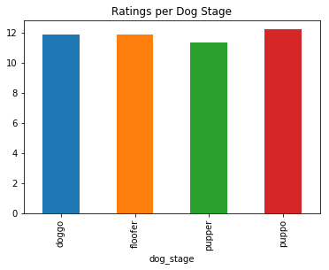

```python
twitter_archive_clean.groupby('dog_stage')['rating_numerator'].mean().plot(kind = 'bar', title = "Ratings per Dog Stage");
```

### Which dog_stage is the most common one?

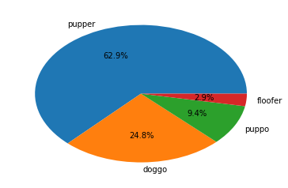

```python
plt.pie(twitter_archive_clean.dog_stage.value_counts(), labels = ['pupper', 'doggo', 'puppo', 'floofer'], autopct='%1.1f%%');
```

```python
twitter_archive_clean.dog_stage.value_counts()
```

```
pupper     193
doggo       76
puppo       29
floofer      9
Name: dog_stage, dtype: int64
```

### Which dog_stage tends to receive the highest favorite_count?

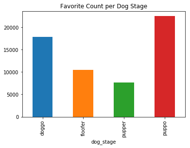

```python
twitter_archive_clean.groupby('dog_stage')['favorite_count'].mean().plot(kind = 'bar', title = "Favorite Count per Dog Stage");
```

```python
twitter_archive_clean.groupby('dog_stage')['favorite_count'].mean()
```

```
dog_stage
doggo      17844.052632
floofer    10512.555556
pupper      7693.430052
puppo      22496.689655
Name: favorite_count, dtype: float64
```

### Which dog_stage tends to receive the highest retweet_count?

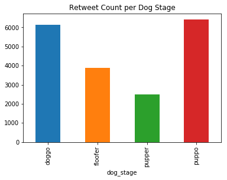

```python
twitter_archive_clean.groupby('dog_stage')['retweet_count'].mean().plot(kind = 'bar', title = "Retweet Count per Dog Stage");
```

```python
twitter_archive_clean.groupby('dog_stage')['retweet_count'].mean()
```

```
dog_stage
doggo      6135.539474
floofer    3876.777778
pupper     2493.414508
puppo      6403.655172
Name: retweet_count, dtype: float64
```

### Which dog_breed is the most common in tweets?

```python
twitter_archive_clean.dog_breed_1.value_counts()
```

```
golden_retriever                  126
Pembroke                           82
Labrador_retriever                 80
Chihuahua                          61
chow                               41
pug                                40
Samoyed                            38
Pomeranian                         37
toy_poodle                         33
malamute                           26
cocker_spaniel                     24
Chesapeake_Bay_retriever           19
Siberian_husky                     19
French_bulldog                     18
Eskimo_dog                         18
miniature_pinscher                 17
German_shepherd                    17
Staffordshire_bullterrier          16
Rottweiler                         15
Cardigan                           15
Shih-Tzu                           14
Shetland_sheepdog                  13
beagle                             13
kuvasz                             13
teddy                              13
Great_Pyrenees                     12
American_Staffordshire_terrier     12
basset                             12
Lakeland_terrier                   12
Maltese_dog                        12
                                 ...
common_iguana                       1
soccer_ball                         1
lakeside                            1
chimpanzee                          1
hay                                 1
African_crocodile                   1
geyser                              1
Angora                              1
pedestal                            1
beach_wagon                         1
cliff                               1
mortarboard                         1
long-horned_beetle                  1
minivan                             1
bighorn                             1
microphone                          1
revolver                            1
quilt                               1
koala                               1
alp                                 1
llama                               1
birdhouse                           1
tiger_shark                         1
leatherback_turtle                  1
cup                                 1
cowboy_boot                         1
sea_lion                            1
silky_terrier                       1
gas_pump                            1
African_grey                        1
Name: dog_breed_1, Length: 256, dtype: int64
```